```python
#Importing libraries

import numpy as np
import pandas as pd
from io import StringIO

import plotly.express as px
import plotly.io as pio
import plotly.figure_factory as ff
from plotnine import *

from stargazer.stargazer import Stargazer
import statsmodels.nonparametric.kernel_regression as loess
from scipy.stats import norm
import statsmodels.api as sm
import statsmodels.formula.api as smf

from helper_funcs import *

from scipy.stats import logistic
from patsy import dmatrices
from sklearn.metrics import mean_squared_error
from sklearn.metrics import r2_score
from sklearn.metrics import log_loss
```

# CHILDREN OBESITY IN ENGLAND

## measuring and prioritizing the main factors

## Introduction

"Today nearly a third of children aged 2 to 15 are overweight or obese, and younger generations are becoming obese at earlier ages and staying obese for longer". By these words the UK government introduced its "Childhood Obesity: a plan for action" report dating back to 2016. Obesity was initally observed as a civilization phenomenon in the 80s in America. Whilst staying limited in Europe, it became a recognised problems in the UK in the 90s and spread across Europe in the new century. Today specialists see it as the number one cause of mortality, having significant impacts on heart desease, cancer and the growing-fast diabetes. The well-known BMI index (the formula is BMI = kg/m2 where kg is a person's weight in kilograms and m2 is their height in metre squared) indicates that **53% of the EU adult population** is considered overweight (BMI>25 - Eurostat 2019).

[figure not shown]

The UK, not showing on this map, is currently at **64%** of its adult population being overweight, i.e. in the Top League of "overweight" European countries.

Analyzing the English perspective (*) has 2 benefits from a research standpoint:

- 1. It was in the first, if not THE first, European countries to identify the problem and make it a national priority, particularly with respect to childhood obesity. This means heavy research and data available in recent years.
- 2. The British government has a very advanced policy on big data and making it widely available to the public, a necessary condition to have access to high-quality data from respected public bodies.

(*): not British, England only for motives of data availability.

## OBJECTIVES

The topics of overweight and obesity have been heavily researched to identify cultural, ethnical, spatial (urbanization), economical, social, educational and motivational factors driving this surge in obesity. Recent political focus has been on nutrition (fruit and vegetable) and physical activity. With the quality of the English data, we will try to have a **thiner** approach to potentially identify **more variables** in the context of chidren overweight and obesity.

## SUMMARY OF FINDINGS

#### Interaction betwwen the 2 children populations

A first regression of 10-11 year old children obesity on 4-5 year old obese showed a very strong correlation between the two. The results are robust and indicate that the percentage of 10-11 year old obese children is 1.8 time the percentage of 4-5 year old children (statistically robust).

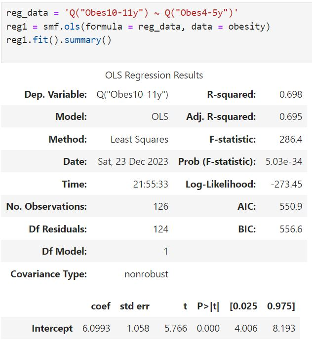

One might think it is an expected result. However a similar regression of overweight children between the age of 10-11 years old on 4-5 year old overweight children shows merely no correlation. We have no explanation for these opposite results, only that htey may respond to different stimuli. The purpose of our research is obesity and we focused all the statistical analysis on the 4-5 year old obese children which represent the highest threat to the English nation's health and potentially the root cause to the obesity development.

#### Social and Psycological = the major interactions

Out of all 16 OLS regressions, 3 psycological factors stand out with an extremely high correlation (and statistically robust _ low CI/P value close to 0):

- Happiness (measured as "high") with R2 at 0.92
- Life satisfaction (measured as "low") with R2 at 0.89
- Anxiety (measured as "high") with R2 at 0.89

This piece of research was conducted by the ONS as part of their Annual Population Survey between January 2017 and December 2019.

This is part of the census conducted by the ONS and completed in March 2021.

The purely economical criteria performed far less strongly:

Last but not least, one factor often criticized, the Fast-Food phenomenon. We used a research conducted by Public Health England in 2015 and compared density of Fast Food outlets by 100.000 inhabitants of the local authorities. R2 comes out at 0,19 with a beta at 0.03: it suggests that every increase of the fast food density by 3% increases the children obesity prevalence by 1 point.

### Final model: 3 variables

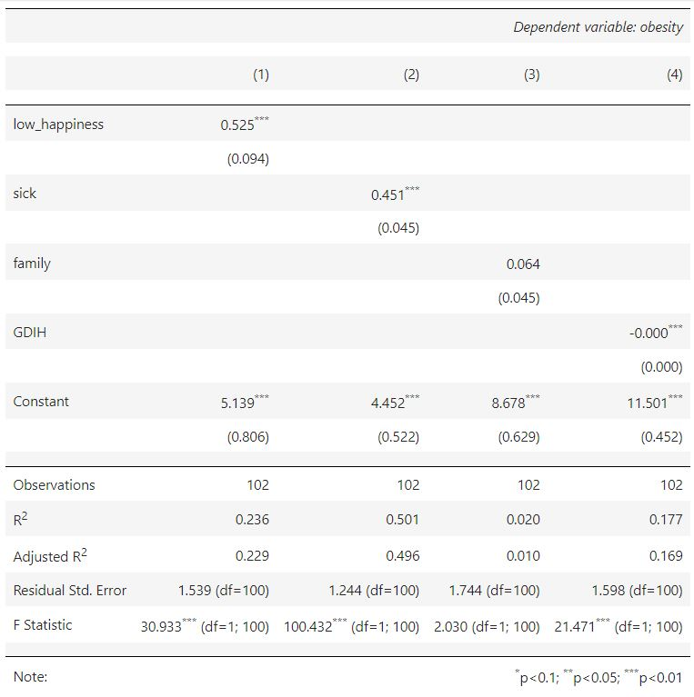

Subsequently the regression on 3 varaibles gives the following results:

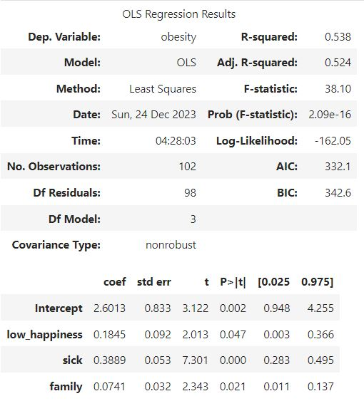

## Data

Major sources of data are the NHS (National Health Service of England), Sportengland (an organization born from this problem to measure and promote physical activity) and Public Health England (governmental). Additional census data was brought in from ONS (Office for National Statistics), UK Data Service and Data.gov.uk (for geographical data). Specific data was added from Trussel Trust (food bank) and Public Health England.

The main information on children obesity is sourced from the NHS: https://digital.nhs.uk/services/national-child-measurement-programme/

### ANALYTICAL TOOLS

#### LOCAL AUHTORITIES

BACKGROUND - SOURCE OF INFORMATION

Local authorities are the finest level of geographical analysis in governmental statistics: kingdom, country, region, county, local authority. There are just over 300 of them in England, which will be the base of our search for variances and possible relationship with multiple factors.

This analysis is on the geographic level, not time based, comparing situations between local authorities on various inputs and outputs. A file with all local authorities' codes and names is produced from a more extensive 'gov UK file'. Downloaded from: www.data.gov.uk/dataset/379b60d5-711a-4c54-8900-fb5151240a0a/ward-to-local-authority-district-to-county-to-region-to-country-december-2022-lookup-in-united-kingdom

```python
# loading file with Local Auhtorities hierarchy
csvfile = pd.read_csv('Ward_to_Local_Authority_District_to_County_to_Region_to_Country_(December_2022)_Lookup_in_United_Kingdom.csv')
la_select = pd.DataFrame(csvfile)
```

```python
# Droping unecessary columns
la_select.drop(['WD22CD', 'WD22NM'], axis = 1, inplace = True)
la_select = la_select.drop_duplicates(subset = 'LAD22CD')
# Selecting L.A. from England (code starting with an "E")
la_select = la_select[la_select['LAD22CD'].str.startswith('E')]
la_select.reset_index(drop = True, inplace = True)
la_select
```

|  | LAD22CD | LAD22NM | CTY22CD | CTY22NM | RGN22CD | RGN22NM | CTRY22CD | CTRY22NM | ObjectId |
| --- | --- | --- | --- | --- | --- | --- | --- | --- | --- |
| 0 | E08000028 | Sandwell | E11000005 | West Midlands | E12000005 | West Midlands | E92000001 | England | 1 |
| 1 | E08000029 | Solihull | E11000005 | West Midlands | E12000005 | West Midlands | E92000001 | England | 22 |
| 2 | E08000030 | Walsall | E11000005 | West Midlands | E12000005 | West Midlands | E92000001 | England | 39 |
| 3 | E08000024 | Sunderland | E11000007 | Tyne and Wear | E12000001 | North East | E92000001 | England | 40 |
| 4 | E08000026 | Coventry | E11000005 | West Midlands | E12000005 | West Midlands | E92000001 | England | 56 |
| ... | ... | ... | ... | ... | ... | ... | ... | ... | ... |
| 304 | E09000025 | Newham | E13000001 | Inner London | E12000007 | London | E92000001 | England | 6764 |
| 305 | E07000246 | Somerset West and Taunton | E10000027 | Somerset | E12000009 | South West | E92000001 | England | 6801 |
| 306 | E07000189 | South Somerset | E10000027 | Somerset | E12000009 | South West | E92000001 | England | 6802 |
| 307 | E07000188 | Sedgemoor | E10000027 | Somerset | E12000009 | South West | E92000001 | England | 6803 |
| 308 | E07000187 | Mendip | E10000027 | Somerset | E12000009 | South West | E92000001 | England | 6821 |

309 rows × 9 columns

```python
# Creating a mini file with Codes and Names of all English local authorities
la_select_short = la_select[["LAD22CD","LAD22NM"]]
la_select_short.rename(columns = {"LAD22CD":"LA code","LAD22NM":"LA name"}, inplace = True)
```

#### LOCAL AUHTORITIES POPULATION

BACKGROUND - SOURCE OF INFORMATION

Last census is dated 2021. Downloaded from UK Data Service: https://statistics.ukdataservice.ac.uk/dataset/population-and-household-estimates-england-and-wales-2021/resource/19f35605-1987-4f27-9a71-2d609b9f9a84

```python
# Loading populatioj file for calculation / ratio purposes
xlfile = pd.read_excel('Population by LA.xlsx')
population = pd.DataFrame(xlfile)
population.rename(columns = {"Usual resident population, 2021":"Pop 2021"}, inplace = True)
population = population[population['LA code'].isin(la_select['LAD22CD'])]
population
```

|  | LA code | LA name | Pop 2021 |
| --- | --- | --- | --- |
| 0 | E06000001 | Hartlepool | 92300.0 |
| 1 | E06000002 | Middlesbrough | 143900.0 |
| 2 | E06000003 | Redcar and Cleveland | 136500.0 |
| 3 | E06000004 | Stockton-on-Tees | 196600.0 |
| 4 | E06000005 | Darlington | 107800.0 |
| ... | ... | ... | ... |
| 304 | E09000029 | Sutton | 209600.0 |
| 305 | E09000030 | Tower Hamlets | 310300.0 |
| 306 | E09000031 | Waltham Forest | 278400.0 |
| 307 | E09000032 | Wandsworth | 327500.0 |
| 308 | E09000033 | Westminster | 204300.0 |

309 rows × 3 columns

### BMI

BACKGROUND - SOURCE OF INFORMATION

The NHS report presents findings from the Government's National Child Measurement Programme (NCMP) for England, 2022/23 school year. It covers children in Reception aged 4-5 years, codified R, and Year 6, aged 10-11 years (codified 6) in mainstream schools in England. The report contains analyses of Body Mass Index (BMI) classification rates by age, sex, deprivation and ethnicity as well as geographic analyses. Although there are differences by gender and by ethnicity, we have excluded these from the research has they were not reported in other sources, focus of this analysis.Full report available in Excel tables at https://digital.nhs.uk/data-and-information/publications/statistical/national-child-measurement-programme/2022-23-school-year

#### R: Children aged 4 to 5 years old

```python
# Loading "NHS" file on weight for children aged 4-5 - BMI R (R stands for Reception - Reception stage of children)
xlfile = pd.read_excel('BMI R by LA percentages.xlsx')
bmiR = pd.DataFrame(xlfile)

# Cleaning up the DataFrame
bmiR.drop(columns = ["Region name"], inplace = True)
bmiR.rename(columns = {'Org code': 'LA code','Obesity (including severe obesity)':'Obesity'}, inplace = True)
bmiR = bmiR[bmiR['LA code'].isin(la_select['LAD22CD'])]

# NHS informs that cells marked "*" have been suppressed for disclosure control purposes
# Replacing '*' by '0'
bmiR[['Underweight', 'Healthy weight', 'Overweight', 'Obesity']
] = bmiR[['Underweight', 'Healthy weight', 'Overweight', 'Obesity']] .replace('*', '0')
bmiR
```

|  | LA code | LA name | Underweight | Healthy weight | Overweight | Obesity |
| --- | --- | --- | --- | --- | --- | --- |
| 11 | E06000047 | County Durham | 0.7 | 73.2 | 14.2 | 11.8 |
| 12 | E06000005 | Darlington | 0.8 | 72.4 | 14.8 | 11.9 |
| 13 | E08000037 | Gateshead | 1.1 | 74.9 | 13.7 | 10.2 |
| 14 | E06000001 | Hartlepool | 0 | 73.7 | 13.2 | 12.7 |
| 15 | E06000002 | Middlesbrough | 1.1 | 73.5 | 12.6 | 12.8 |
| ... | ... | ... | ... | ... | ... | ... |
| 156 | E06000026 | Plymouth | 0.4 | 76.1 | 13.7 | 9.7 |
| 158 | E06000025 | South Gloucestershire | 1.1 | 82.9 | 9.6 | 6.5 |
| 159 | E06000030 | Swindon | 1.6 | 77.8 | 11.7 | 8.8 |
| 160 | E06000027 | Torbay | 0.8 | 78.2 | 11.8 | 9.2 |
| 161 | E06000054 | Wiltshire | 0.6 | 79.3 | 11.8 | 8.3 |

126 rows × 6 columns

#### 6: Children aged 10 to 11 years old

```python
# Loading "NHS" file on weight for children aged 10-11
xlfile = pd.read_excel('BMI 6 by LA percentages.xlsx')
bmi6 = pd.DataFrame(xlfile)

# Cleaning the DataFrame
bmi6.drop(columns = ["Region name"], inplace = True)
bmi6.rename(columns = {'Org code': 'LA code','Obesity (including severe obesity)':'Obesity'}, inplace = True)
bmi6 = bmi6[bmi6['LA code'].isin(la_select['LAD22CD'])]

# NHS informs that cells marked "*" have been suppressed for disclosure control purposes
# Replacing '*' by '0'
bmi6[['Underweight', 'Healthy weight', 'Overweight', 'Obesity']
] = bmi6[['Underweight', 'Healthy weight', 'Overweight', 'Obesity']] .replace('*', '0')
bmi6.rename(columns = {'Underweight':'Underweight6', 'Healthy weight':'Healthy weight6', 'Overweight':'Overweight6', 'Obesity':'Obesity6'}, inplace = True)
bmi6
```

|  | LA code | LA name | Underweight6 | Healthy weight6 | Overweight6 | Obesity6 |
| --- | --- | --- | --- | --- | --- | --- |
| 11 | E06000047 | County Durham | 1.1 | 59.0 | 14.2 | 25.7 |
| 12 | E06000005 | Darlington | 1.6 | 61.2 | 12.9 | 24.3 |
| 13 | E08000037 | Gateshead | 1.2 | 60.8 | 13.5 | 24.3 |
| 14 | E06000001 | Hartlepool | 0.8 | 57.7 | 14.9 | 26.6 |
| 15 | E06000002 | Middlesbrough | 0.8 | 57.0 | 13.5 | 28.5 |
| ... | ... | ... | ... | ... | ... | ... |
| 156 | E06000026 | Plymouth | 1.5 | 64.7 | 13.7 | 19.9 |
| 158 | E06000025 | South Gloucestershire | 1.8 | 66.1 | 13.2 | 18.8 |
| 159 | E06000030 | Swindon | 1.6 | 61.8 | 14.1 | 22.2 |
| 160 | E06000027 | Torbay | 1.5 | 62.8 | 14.3 | 21.4 |
| 161 | E06000054 | Wiltshire | 1.4 | 65.8 | 13.5 | 19.3 |

126 rows × 6 columns

```python
# Checking that each file share the same L.A. structure
check_identical = bmiR['LA code'].equals(bmi6['LA code'])
print(check_identical)
```

```
True
```

```python
# Creating an "Overweight" table with both age groups
overw = pd.concat([bmiR[['LA code']], bmiR[['Overweight']], bmi6[['Overweight6']]], axis = 1)
overw = overw.rename(columns = {'Overweight':'Ovw4-5y', 'Overweight6':'Ovw10-11y'})
overw
```

|  | LA code | Ovw4-5y | Ovw10-11y |
| --- | --- | --- | --- |
| 11 | E06000047 | 14.2 | 14.2 |
| 12 | E06000005 | 14.8 | 12.9 |
| 13 | E08000037 | 13.7 | 13.5 |
| 14 | E06000001 | 13.2 | 14.9 |
| 15 | E06000002 | 12.6 | 13.5 |
| ... | ... | ... | ... |
| 156 | E06000026 | 13.7 | 13.7 |
| 158 | E06000025 | 9.6 | 13.2 |
| 159 | E06000030 | 11.7 | 14.1 |
| 160 | E06000027 | 11.8 | 14.3 |
| 161 | E06000054 | 11.8 | 13.5 |

126 rows × 3 columns

```python
# Creating an "Obesity" table with both age groups
obesity = pd.concat([bmiR[['LA code']], bmiR[['Obesity']], bmi6[['Obesity6']]], axis = 1)
obesity = obesity.rename(columns = {'Obesity':'Obes4-5y', 'Obesity6':'Obes10-11y'})
obesity
```

|  | LA code | Obes4-5y | Obes10-11y |
| --- | --- | --- | --- |
| 11 | E06000047 | 11.8 | 25.7 |
| 12 | E06000005 | 11.9 | 24.3 |
| 13 | E08000037 | 10.2 | 24.3 |
| 14 | E06000001 | 12.7 | 26.6 |
| 15 | E06000002 | 12.8 | 28.5 |
| ... | ... | ... | ... |
| 156 | E06000026 | 9.7 | 19.9 |
| 158 | E06000025 | 6.5 | 18.8 |
| 159 | E06000030 | 8.8 | 22.2 |
| 160 | E06000027 | 9.2 | 21.4 |
| 161 | E06000054 | 8.3 | 19.3 |

126 rows × 3 columns

```python
# Regression analysis of age group on the other
reg_data = 'Q("Obes10-11y") ~ Q("Obes4-5y")'
reg1 = smf.ols(formula = reg_data, data = obesity)
reg1.fit().summary()
```

OLS Regression Results

| Dep. Variable: | Q("Obes10-11y") | R-squared: | 0.698 |
| --- | --- | --- | --- |
| Model: | OLS | Adj. R-squared: | 0.695 |
| Method: | Least Squares | F-statistic: | 286.4 |
| Date: | Sun, 24 Dec 2023 | Prob (F-statistic): | 5.03e-34 |
| Time: | 04:19:20 | Log-Likelihood: | -273.45 |
| No. Observations: | 126 | AIC: | 550.9 |
| Df Residuals: | 124 | BIC: | 556.6 |
| Df Model: | 1 |  |  |
| Covariance Type: | nonrobust |  |  |

|  | coef | std err | t | P>\|t\| | [0.025 | 0.975] |
| --- | --- | --- | --- | --- | --- | --- |
| Intercept | 6.0993 | 1.058 | 5.766 | 0.000 | 4.006 | 8.193 |
| Q("Obes4-5y") | 1.8428 | 0.109 | 16.925 | 0.000 | 1.627 | 2.058 |

| Omnibus: | 1.151 | Durbin-Watson: | 1.806 |
| --- | --- | --- | --- |
| Prob(Omnibus): | 0.562 | Jarque-Bera (JB): | 1.070 |
| Skew: | 0.047 | Prob(JB): | 0.586 |
| Kurtosis: | 2.559 | Cond. No. | 54.5 |

Notes:  
[1] Standard Errors assume that the covariance matrix of the errors is correctly specified.

```python
# Regression of one age group on the other for Overweight children
reg_data = 'Q("Ovw10-11y") ~ Q("Ovw4-5y")'
reg2 = smf.ols(formula = reg_data, data = overw)
reg2.fit().summary()
```

OLS Regression Results

| Dep. Variable: | Q("Ovw10-11y") | R-squared: | 0.005 |
| --- | --- | --- | --- |
| Model: | OLS | Adj. R-squared: | -0.003 |
| Method: | Least Squares | F-statistic: | 0.5946 |
| Date: | Sun, 24 Dec 2023 | Prob (F-statistic): | 0.442 |
| Time: | 04:19:23 | Log-Likelihood: | -144.68 |
| No. Observations: | 126 | AIC: | 293.4 |
| Df Residuals: | 124 | BIC: | 299.0 |
| Df Model: | 1 |  |  |
| Covariance Type: | nonrobust |  |  |

|  | coef | std err | t | P>\|t\| | [0.025 | 0.975] |
| --- | --- | --- | --- | --- | --- | --- |
| Intercept | 13.6614 | 0.506 | 27.025 | 0.000 | 12.661 | 14.662 |
| Q("Ovw4-5y") | 0.0320 | 0.041 | 0.771 | 0.442 | -0.050 | 0.114 |

| Omnibus: | 2.133 | Durbin-Watson: | 1.749 |
| --- | --- | --- | --- |
| Prob(Omnibus): | 0.344 | Jarque-Bera (JB): | 1.843 |
| Skew: | 0.036 | Prob(JB): | 0.398 |
| Kurtosis: | 3.588 | Cond. No. | 90.6 |

Notes:  
[1] Standard Errors assume that the covariance matrix of the errors is correctly specified.

### PHYSICAL ACTIVITY

In 1996 an amended Royal Charter established The English Sports Council, which came into being on 1 January 1997 as The Sports Council was reorganised into UK Sport and the home nations sports councils – we were then rebranded as Sport England in 1"999. https://www.sportengland.org/research-and-data/data

```python
# Loading "loneliness" file
xlfile = pd.read_excel('ActiveLivesDataExport - Loneliness (years 7-11) mod.xlsx', skiprows=2)
loneliness = pd.DataFrame(xlfile)
loneliness
```

|  | Unnamed: 0 | Often / always | Some of the time | Occasionally | Hardly ever | Never |
| --- | --- | --- | --- | --- | --- | --- |
| 0 | East Region | 10.5% | 22.8% | 27.2% | 30.7% | 8.8% |
| 1 | East Midlands Region | 12.1% | 24.7% | 25.4% | 28.4% | 9.4% |
| 2 | London Region | 11.9% | 21.8% | 25.8% | 29.8% | 10.7% |
| 3 | North East Region | 11.2% | 23.9% | 26.2% | 29.1% | 9.5% |
| 4 | North West Region | 10.4% | 22.8% | 25.8% | 29.7% | 11.3% |
| ... | ... | ... | ... | ... | ... | ... |
| 386 | Urban Minor Conurbation | 12.7% | 25.5% | 25.2% | 28.1% | 8.5% |
| 387 | Urban City and Town (Sparse and Non Sparse) | 11.4% | 24.1% | 26.4% | 28.8% | 9.3% |
| 388 | Rural Town (Sparse and Non Sparse) | 12.3% | 24.4% | 25.8% | 28.2% | 9.2% |
| 389 | Rural Village (Sparse and Non Sparse) | 10.1% | 21.9% | 26.9% | 32.4% | 8.6% |
| 390 | Rural Hamlets (Sparse and Non Sparse) | 6.5% | 22.6% | 29.3% | 31.8% | 9.8% |

391 rows × 6 columns

```python
# Setting up the file / selecting the English L.A.
loneliness.rename(columns = {loneliness.columns[0]: 'Areas'}, inplace = True)
loneliness = loneliness[loneliness['Areas'].str.endswith(' LA')]
loneliness['Areas'] = loneliness['Areas'].str[:-3]
loneliness = loneliness[loneliness['Areas'].isin(la_select['LAD22NM'])]
valid_rows = loneliness[loneliness['Often / always'] != '-']['Often / always'].count()
# Displaying the result
print(valid_rows)
```

```
55
```

##### Too many empty cells on this item, dropped for further analysis

```python
# Setting up the "Competence" file / selecting the English L.A.
csvfile = pd.read_csv('ActiveLivesDataExport_Competence - I find exercise and sports easy (years 3-11) - Strongly agree.csv', skiprows=3)
sporteasy = pd.DataFrame(csvfile)
sporteasy.rename(columns = {sporteasy.columns[0]: 'LA name',"Academic Year 21-22":"strongly_agree"}, inplace = True)
sporteasy.drop(columns = ["Academic Year 17-18","Academic Year 18-19","Academic Year 19-20","Academic Year 20-21"], inplace = True)
sporteasy = sporteasy[sporteasy['LA name'].str.endswith(' LA')]
sporteasy['LA name'] = sporteasy['LA name'].str[:-3]
sporteasy = sporteasy[sporteasy['LA name'].isin(la_select['LAD22NM'])]
sporteasy = pd.merge(sporteasy, la_select_short, on = 'LA name')
valid_rows = sporteasy[sporteasy['strongly_agree'] != '-']['strongly_agree'].count()
# Checking number of observations and content
print(valid_rows)
sporteasy
```

```
186
```

|  | LA name | strongly_agree | LA code |
| --- | --- | --- | --- |
| 0 | Adur | - | E07000223 |
| 1 | Amber Valley | - | E07000032 |
| 2 | Arun | - | E07000224 |
| 3 | Ashfield | 18.7% | E07000170 |
| 4 | Ashford | - | E07000105 |
| 5 | Babergh | 29.0% | E07000200 |
| 6 | Barking and Dagenham | - | E09000002 |
| 7 | Barnet | - | E09000003 |
| 8 | Barnsley | 30.9% | E08000016 |
| 9 | Basildon | 18.2% | E07000066 |
| 10 | Basingstoke and Deane | 18.8% | E07000084 |
| 11 | Bassetlaw | 19.2% | E07000171 |
| 12 | Bath and North East Somerset | - | E06000022 |
| 13 | Bedford | 16.6% | E06000055 |
| 14 | Bexley | 16.6% | E09000004 |
| 15 | Birmingham | 17.3% | E08000025 |
| 16 | Blaby | - | E07000129 |
| 17 | Blackburn with Darwen | 20.0% | E06000008 |
| 18 | Blackpool | 17.3% | E06000009 |
| 19 | Bolsover | 21.2% | E07000033 |
| 20 | Bolton | 20.3% | E08000001 |
| 21 | Boston | - | E07000136 |
| 22 | Bournemouth, Christchurch and Poole | 20.6% | E06000058 |
| 23 | Bracknell Forest | - | E06000036 |
| 24 | Bradford | 21.4% | E08000032 |
| 25 | Braintree | 19.9% | E07000067 |
| 26 | Breckland | - | E07000143 |
| 27 | Brent | - | E09000005 |
| 28 | Brentwood | 22.3% | E07000068 |
| 29 | Brighton and Hove | 13.7% | E06000043 |

[output cut: 254 more lines]

```python
# Merging with obesity file for regression purposes
data = pd.merge(obesity, sporteasy, how = 'inner', on = 'LA code')
reg_data = 'Q("Obes4-5y") ~ Q("strongly_agree")'
regr1 = smf.ols(formula = reg_data, data = data)
result = regr1.fit()
result.summary()
```

OLS Regression Results

| Dep. Variable: | Q("Obes4-5y") | R-squared: | 0.441 |
| --- | --- | --- | --- |
| Model: | OLS | Adj. R-squared: | -0.108 |
| Method: | Least Squares | F-statistic: | 0.8027 |
| Date: | Sun, 24 Dec 2023 | Prob (F-statistic): | 0.802 |
| Time: | 04:20:19 | Log-Likelihood: | -206.38 |
| No. Observations: | 122 | AIC: | 534.8 |
| Df Residuals: | 61 | BIC: | 705.8 |
| Df Model: | 60 |  |  |
| Covariance Type: | nonrobust |  |  |

|  | coef | std err | t | P>\|t\| | [0.025 | 0.975] |
| --- | --- | --- | --- | --- | --- | --- |
| Intercept | 9.1468 | 0.271 | 33.757 | 0.000 | 8.605 | 9.689 |
| Q("strongly_agree")[T.13.7%] | -2.3468 | 1.877 | -1.250 | 0.216 | -6.101 | 1.407 |
| Q("strongly_agree")[T.13.9%] | -0.0468 | 1.877 | -0.025 | 0.980 | -3.801 | 3.707 |
| Q("strongly_agree")[T.14.2%] | -1.5468 | 1.877 | -0.824 | 0.413 | -5.301 | 2.207 |
| Q("strongly_agree")[T.14.5%] | -1.0468 | 1.877 | -0.558 | 0.579 | -4.801 | 2.707 |
| Q("strongly_agree")[T.15.9%] | 0.9032 | 1.341 | 0.673 | 0.503 | -1.779 | 3.585 |
| Q("strongly_agree")[T.16.6%] | -0.0135 | 1.106 | -0.012 | 0.990 | -2.225 | 2.198 |
| Q("strongly_agree")[T.16.9%] | 2.0532 | 1.877 | 1.094 | 0.278 | -1.701 | 5.807 |
| Q("strongly_agree")[T.17.2%] | -1.1468 | 1.877 | -0.611 | 0.544 | -4.901 | 2.607 |
| Q("strongly_agree")[T.17.3%] | 0.1532 | 0.968 | 0.158 | 0.875 | -1.781 | 2.088 |
| Q("strongly_agree")[T.17.6%] | -1.4468 | 1.341 | -1.079 | 0.285 | -4.129 | 1.235 |
| Q("strongly_agree")[T.17.8%] | -2.6468 | 1.877 | -1.410 | 0.164 | -6.401 | 1.107 |
| Q("strongly_agree")[T.18.1%] | 0.0532 | 1.877 | 0.028 | 0.977 | -3.701 | 3.807 |
| Q("strongly_agree")[T.18.2%] | -0.0968 | 1.341 | -0.072 | 0.943 | -2.779 | 2.585 |
| Q("strongly_agree")[T.18.3%] | 1.6199 | 1.106 | 1.464 | 0.148 | -0.592 | 3.832 |
| Q("strongly_agree")[T.18.6%] | 2.3532 | 1.877 | 1.254 | 0.215 | -1.401 | 6.107 |
| Q("strongly_agree")[T.18.8%] | 1.2532 | 1.877 | 0.668 | 0.507 | -2.501 | 5.007 |
| Q("strongly_agree")[T.18.9%] | -1.0468 | 1.877 | -0.558 | 0.579 | -4.801 | 2.707 |
| Q("strongly_agree")[T.19.0%] | 2.3532 | 1.877 | 1.254 | 0.215 | -1.401 | 6.107 |
| Q("strongly_agree")[T.19.1%] | 0.8532 | 1.877 | 0.454 | 0.651 | -2.901 | 4.607 |
| Q("strongly_agree")[T.19.3%] | 2.3532 | 1.877 | 1.254 | 0.215 | -1.401 | 6.107 |
| Q("strongly_agree")[T.19.5%] | 0.9532 | 1.877 | 0.508 | 0.613 | -2.801 | 4.707 |
| Q("strongly_agree")[T.19.6%] | 0.3532 | 1.877 | 0.188 | 0.851 | -3.401 | 4.107 |
| Q("strongly_agree")[T.19.7%] | 1.2532 | 1.877 | 0.668 | 0.507 | -2.501 | 5.007 |
| Q("strongly_agree")[T.20.0%] | 1.2532 | 1.877 | 0.668 | 0.507 | -2.501 | 5.007 |
| Q("strongly_agree")[T.20.3%] | 1.8532 | 1.877 | 0.987 | 0.327 | -1.901 | 5.607 |
| Q("strongly_agree")[T.20.6%] | -2.2468 | 1.877 | -1.197 | 0.236 | -6.001 | 1.507 |
| Q("strongly_agree")[T.21.1%] | 1.7532 | 1.877 | 0.934 | 0.354 | -2.001 | 5.507 |
| Q("strongly_agree")[T.21.3%] | 2.5532 | 1.877 | 1.360 | 0.179 | -1.201 | 6.307 |
| Q("strongly_agree")[T.21.4%] | 0.5532 | 1.877 | 0.295 | 0.769 | -3.201 | 4.307 |
| Q("strongly_agree")[T.21.6%] | -2.0468 | 1.877 | -1.090 | 0.280 | -5.801 | 1.707 |
| Q("strongly_agree")[T.21.8%] | 1.5532 | 1.341 | 1.158 | 0.251 | -1.129 | 4.235 |
| Q("strongly_agree")[T.21.9%] | 1.2032 | 1.341 | 0.897 | 0.373 | -1.479 | 3.885 |
| Q("strongly_agree")[T.22.0%] | 1.3199 | 1.106 | 1.193 | 0.237 | -0.892 | 3.532 |
| Q("strongly_agree")[T.22.3%] | 3.6532 | 1.877 | 1.946 | 0.056 | -0.101 | 7.407 |
| Q("strongly_agree")[T.22.5%] | 2.7532 | 1.877 | 1.467 | 0.148 | -1.001 | 6.507 |
| Q("strongly_agree")[T.22.6%] | 0.5532 | 1.877 | 0.295 | 0.769 | -3.201 | 4.307 |
| Q("strongly_agree")[T.22.9%] | -0.5468 | 1.877 | -0.291 | 0.772 | -4.301 | 3.207 |
| Q("strongly_agree")[T.23.0%] | 0.2532 | 1.877 | 0.135 | 0.893 | -3.501 | 4.007 |
| Q("strongly_agree")[T.23.1%] | 0.4532 | 1.877 | 0.241 | 0.810 | -3.301 | 4.207 |
| Q("strongly_agree")[T.23.3%] | 0.2532 | 1.877 | 0.135 | 0.893 | -3.501 | 4.007 |
| Q("strongly_agree")[T.23.4%] | 1.6532 | 1.877 | 0.881 | 0.382 | -2.101 | 5.407 |
| Q("strongly_agree")[T.23.7%] | 0.1532 | 1.877 | 0.082 | 0.935 | -3.601 | 3.907 |
| Q("strongly_agree")[T.23.8%] | 2.4532 | 1.877 | 1.307 | 0.196 | -1.301 | 6.207 |
| Q("strongly_agree")[T.24.0%] | -2.5468 | 1.877 | -1.357 | 0.180 | -6.301 | 1.207 |
| Q("strongly_agree")[T.24.2%] | 1.1532 | 1.877 | 0.614 | 0.541 | -2.601 | 4.907 |
| Q("strongly_agree")[T.24.3%] | 2.4532 | 1.341 | 1.829 | 0.072 | -0.229 | 5.135 |
| Q("strongly_agree")[T.24.8%] | -0.0468 | 1.877 | -0.025 | 0.980 | -3.801 | 3.707 |
| Q("strongly_agree")[T.24.9%] | -0.2468 | 1.877 | -0.131 | 0.896 | -4.001 | 3.507 |
| Q("strongly_agree")[T.25.2%] | -0.1468 | 1.877 | -0.078 | 0.938 | -3.901 | 3.607 |
| Q("strongly_agree")[T.25.5%] | 2.4532 | 1.877 | 1.307 | 0.196 | -1.301 | 6.207 |
| Q("strongly_agree")[T.25.7%] | -2.2468 | 1.877 | -1.197 | 0.236 | -6.001 | 1.507 |
| Q("strongly_agree")[T.25.9%] | 1.7532 | 1.877 | 0.934 | 0.354 | -2.001 | 5.507 |
| Q("strongly_agree")[T.27.2%] | 0.2532 | 1.877 | 0.135 | 0.893 | -3.501 | 4.007 |
| Q("strongly_agree")[T.27.5%] | 4.3532 | 1.877 | 2.319 | 0.024 | 0.599 | 8.107 |
| Q("strongly_agree")[T.28.0%] | 0.2532 | 1.877 | 0.135 | 0.893 | -3.501 | 4.007 |
| Q("strongly_agree")[T.28.1%] | 0.5532 | 1.877 | 0.295 | 0.769 | -3.201 | 4.307 |
| Q("strongly_agree")[T.29.0%] | 2.0532 | 1.877 | 1.094 | 0.278 | -1.701 | 5.807 |
| Q("strongly_agree")[T.29.5%] | 0.0532 | 1.877 | 0.028 | 0.977 | -3.701 | 3.807 |
| Q("strongly_agree")[T.30.9%] | 0.6532 | 1.877 | 0.348 | 0.729 | -3.101 | 4.407 |
| Q("strongly_agree")[T.9.5%] | 0.3532 | 1.877 | 0.188 | 0.851 | -3.401 | 4.107 |

| Omnibus: | 11.115 | Durbin-Watson: | 1.979 |
| --- | --- | --- | --- |
| Prob(Omnibus): | 0.004 | Jarque-Bera (JB): | 25.030 |
| Skew: | 0.234 | Prob(JB): | 3.67e-06 |
| Kurtosis: | 5.169 | Cond. No. | 16.5 |

Notes:  
[1] Standard Errors assume that the covariance matrix of the errors is correctly specified.

```python
# Loading the "Confidence" file
csvfile = pd.read_csv('ActiveLivesDataExport_Confidence - I feel confident when I exercise and play sports (years 3-11) - Strongly agree.csv', skiprows = 3)
sportconfident = pd.DataFrame(csvfile)

# Checking type of data
sportconfident.dtypes
```

```
Unnamed: 0             object
Academic Year 17-18    object
Academic Year 18-19    object
Academic Year 19-20    object
Academic Year 20-21    object
Academic Year 21-22    object
dtype: object
```

```python
# Setting up the file / Selecting the L.A.
sportconfident.rename(columns = {sportconfident.columns[0]: 'LA name',"Academic Year 21-22":"strongly_agree"}, inplace = True)
sportconfident.drop(columns = ["Academic Year 17-18","Academic Year 18-19","Academic Year 19-20","Academic Year 20-21"], inplace = True)
sportconfident = sportconfident[sportconfident['LA name'].str.endswith(' LA')]
sportconfident['LA name'] = sportconfident['LA name'].str[:-3]
sportconfident = sportconfident[sportconfident['LA name'].isin(la_select['LAD22NM'])]
sportconfident = pd.merge(sportconfident, la_select_short, on = 'LA name')

# Cheecking for data quality and number of observations
valid_rows = sportconfident[sportconfident['strongly_agree'] != '-']['strongly_agree'].count()
print(valid_rows)
sportconfident
```

```
199
```

|  | LA name | strongly_agree | LA code |
| --- | --- | --- | --- |
| 0 | Adur | - | E07000223 |
| 1 | Amber Valley | 21.0% | E07000032 |
| 2 | Arun | - | E07000224 |
| 3 | Ashfield | 31.1% | E07000170 |
| 4 | Ashford | - | E07000105 |
| 5 | Babergh | 38.2% | E07000200 |
| 6 | Barking and Dagenham | - | E09000002 |
| 7 | Barnet | - | E09000003 |
| 8 | Barnsley | 43.0% | E08000016 |
| 9 | Basildon | 33.3% | E07000066 |
| 10 | Basingstoke and Deane | 29.2% | E07000084 |
| 11 | Bassetlaw | 38.6% | E07000171 |
| 12 | Bath and North East Somerset | - | E06000022 |
| 13 | Bedford | 40.4% | E06000055 |
| 14 | Bexley | 34.4% | E09000004 |
| 15 | Birmingham | 39.3% | E08000025 |
| 16 | Blaby | - | E07000129 |
| 17 | Blackburn with Darwen | 33.9% | E06000008 |
| 18 | Blackpool | 27.3% | E06000009 |
| 19 | Bolsover | 30.6% | E07000033 |
| 20 | Bolton | 44.3% | E08000001 |
| 21 | Boston | - | E07000136 |
| 22 | Bournemouth, Christchurch and Poole | 35.0% | E06000058 |
| 23 | Bracknell Forest | 37.7% | E06000036 |
| 24 | Bradford | 42.3% | E08000032 |
| 25 | Braintree | 36.2% | E07000067 |
| 26 | Breckland | - | E07000143 |
| 27 | Brent | - | E09000005 |
| 28 | Brentwood | 36.9% | E07000068 |
| 29 | Brighton and Hove | 36.3% | E06000043 |

[output cut: 254 more lines]

```python
# Merging with weight data
data = pd.merge(obesity, sportconfident, how = 'inner', on = 'LA code')

# Regression of weight
reg_data = 'Q("Obes4-5y") ~ Q("strongly_agree")'
regr2 = smf.ols(formula = reg_data, data = data)
result = regr2.fit()
result.summary()
```

OLS Regression Results

| Dep. Variable: | Q("Obes4-5y") | R-squared: | 0.510 |
| --- | --- | --- | --- |
| Model: | OLS | Adj. R-squared: | -0.058 |
| Method: | Least Squares | F-statistic: | 0.8979 |
| Date: | Sun, 24 Dec 2023 | Prob (F-statistic): | 0.664 |
| Time: | 04:22:45 | Log-Likelihood: | -198.33 |
| No. Observations: | 122 | AIC: | 528.7 |
| Df Residuals: | 56 | BIC: | 713.7 |
| Df Model: | 65 |  |  |
| Covariance Type: | nonrobust |  |  |

|  | coef | std err | t | P>\|t\| | [0.025 | 0.975] |
| --- | --- | --- | --- | --- | --- | --- |
| Intercept | 9.1650 | 0.287 | 31.939 | 0.000 | 8.590 | 9.740 |
| Q("strongly_agree")[T.24.2%] | 1.5350 | 1.837 | 0.835 | 0.407 | -2.146 | 5.216 |
| Q("strongly_agree")[T.24.7%] | 0.4350 | 1.837 | 0.237 | 0.814 | -3.246 | 4.116 |
| Q("strongly_agree")[T.24.9%] | 4.3350 | 1.837 | 2.359 | 0.022 | 0.654 | 8.016 |
| Q("strongly_agree")[T.25.0%] | -1.3650 | 1.315 | -1.038 | 0.304 | -3.999 | 1.269 |
| Q("strongly_agree")[T.25.5%] | 0.8350 | 1.837 | 0.454 | 0.651 | -2.846 | 4.516 |
| Q("strongly_agree")[T.27.3%] | 2.8350 | 1.837 | 1.543 | 0.128 | -0.846 | 6.516 |
| Q("strongly_agree")[T.27.7%] | 1.2350 | 1.837 | 0.672 | 0.504 | -2.446 | 4.916 |
| Q("strongly_agree")[T.29.3%] | -2.6650 | 1.837 | -1.450 | 0.153 | -6.346 | 1.016 |
| Q("strongly_agree")[T.29.5%] | 0.7350 | 1.315 | 0.559 | 0.578 | -1.899 | 3.369 |
| Q("strongly_agree")[T.29.6%] | 1.9350 | 1.837 | 1.053 | 0.297 | -1.746 | 5.616 |
| Q("strongly_agree")[T.29.7%] | -2.9650 | 1.837 | -1.614 | 0.112 | -6.646 | 0.716 |
| Q("strongly_agree")[T.30.0%] | -2.3650 | 1.837 | -1.287 | 0.203 | -6.046 | 1.316 |
| Q("strongly_agree")[T.30.4%] | 3.0350 | 1.837 | 1.652 | 0.104 | -0.646 | 6.716 |
| Q("strongly_agree")[T.30.7%] | 0.0350 | 1.837 | 0.019 | 0.985 | -3.646 | 3.716 |
| Q("strongly_agree")[T.31.1%] | -0.8650 | 1.837 | -0.471 | 0.640 | -4.546 | 2.816 |
| Q("strongly_agree")[T.31.2%] | 0.1350 | 1.837 | 0.073 | 0.942 | -3.546 | 3.816 |
| Q("strongly_agree")[T.31.5%] | 2.6350 | 1.837 | 1.434 | 0.157 | -1.046 | 6.316 |
| Q("strongly_agree")[T.31.7%] | -0.4650 | 1.837 | -0.253 | 0.801 | -4.146 | 3.216 |
| Q("strongly_agree")[T.31.9%] | -0.0650 | 1.837 | -0.035 | 0.972 | -3.746 | 3.616 |
| Q("strongly_agree")[T.32.0%] | 0.6350 | 1.315 | 0.483 | 0.631 | -1.999 | 3.269 |
| Q("strongly_agree")[T.32.3%] | 0.6350 | 1.315 | 0.483 | 0.631 | -1.999 | 3.269 |
| Q("strongly_agree")[T.32.5%] | -0.9650 | 1.837 | -0.525 | 0.602 | -4.646 | 2.716 |
| Q("strongly_agree")[T.32.6%] | -0.4650 | 1.837 | -0.253 | 0.801 | -4.146 | 3.216 |
| Q("strongly_agree")[T.32.8%] | 0.5350 | 1.837 | 0.291 | 0.772 | -3.146 | 4.216 |
| Q("strongly_agree")[T.33.2%] | 0.5350 | 1.837 | 0.291 | 0.772 | -3.146 | 4.216 |
| Q("strongly_agree")[T.33.3%] | 0.0683 | 1.086 | 0.063 | 0.950 | -2.108 | 2.245 |
| Q("strongly_agree")[T.33.6%] | 2.2350 | 1.837 | 1.216 | 0.229 | -1.446 | 5.916 |
| Q("strongly_agree")[T.33.9%] | 1.2350 | 1.837 | 0.672 | 0.504 | -2.446 | 4.916 |
| Q("strongly_agree")[T.34.2%] | -1.4650 | 1.837 | -0.797 | 0.429 | -5.146 | 2.216 |
| Q("strongly_agree")[T.34.4%] | 0.3350 | 1.837 | 0.182 | 0.856 | -3.346 | 4.016 |
| Q("strongly_agree")[T.35.0%] | -2.2650 | 1.837 | -1.233 | 0.223 | -5.946 | 1.416 |
| Q("strongly_agree")[T.35.2%] | 2.3350 | 1.837 | 1.271 | 0.209 | -1.346 | 6.016 |
| Q("strongly_agree")[T.35.3%] | 1.1350 | 1.837 | 0.618 | 0.539 | -2.546 | 4.816 |
| Q("strongly_agree")[T.35.5%] | 0.0350 | 1.837 | 0.019 | 0.985 | -3.646 | 3.716 |
| Q("strongly_agree")[T.35.8%] | -2.2650 | 1.837 | -1.233 | 0.223 | -5.946 | 1.416 |
| Q("strongly_agree")[T.36.0%] | 3.2350 | 1.837 | 1.761 | 0.084 | -0.446 | 6.916 |
| Q("strongly_agree")[T.36.3%] | -1.1650 | 1.315 | -0.886 | 0.379 | -3.799 | 1.469 |
| Q("strongly_agree")[T.36.4%] | -0.0650 | 1.837 | -0.035 | 0.972 | -3.746 | 3.616 |
| Q("strongly_agree")[T.36.5%] | 1.7350 | 1.837 | 0.944 | 0.349 | -1.946 | 5.416 |
| Q("strongly_agree")[T.36.7%] | 0.2350 | 1.837 | 0.128 | 0.899 | -3.446 | 3.916 |
| Q("strongly_agree")[T.36.8%] | 3.1850 | 1.315 | 2.422 | 0.019 | 0.551 | 5.819 |
| Q("strongly_agree")[T.37.0%] | 0.5350 | 1.837 | 0.291 | 0.772 | -3.146 | 4.216 |
| Q("strongly_agree")[T.37.1%] | 0.1350 | 1.837 | 0.073 | 0.942 | -3.546 | 3.816 |
| Q("strongly_agree")[T.37.3%] | 0.4350 | 1.837 | 0.237 | 0.814 | -3.246 | 4.116 |
| Q("strongly_agree")[T.37.4%] | -0.3650 | 1.837 | -0.199 | 0.843 | -4.046 | 3.316 |
| Q("strongly_agree")[T.37.6%] | -2.0650 | 1.837 | -1.124 | 0.266 | -5.746 | 1.616 |
| Q("strongly_agree")[T.37.7%] | -1.9650 | 1.837 | -1.069 | 0.289 | -5.646 | 1.716 |
| Q("strongly_agree")[T.37.9%] | 1.2850 | 1.315 | 0.977 | 0.333 | -1.349 | 3.919 |
| Q("strongly_agree")[T.38.0%] | 2.9850 | 1.315 | 2.270 | 0.027 | 0.351 | 5.619 |
| Q("strongly_agree")[T.38.6%] | 1.0850 | 1.315 | 0.825 | 0.413 | -1.549 | 3.719 |
| Q("strongly_agree")[T.38.8%] | 0.0350 | 1.837 | 0.019 | 0.985 | -3.646 | 3.716 |
| Q("strongly_agree")[T.38.9%] | 2.8350 | 1.837 | 1.543 | 0.128 | -0.846 | 6.516 |
| Q("strongly_agree")[T.39.3%] | 0.6350 | 1.315 | 0.483 | 0.631 | -1.999 | 3.269 |
| Q("strongly_agree")[T.39.4%] | -0.2650 | 1.315 | -0.202 | 0.841 | -2.899 | 2.369 |
| Q("strongly_agree")[T.40.4%] | -0.8650 | 1.837 | -0.471 | 0.640 | -4.546 | 2.816 |
| Q("strongly_agree")[T.41.7%] | 2.0350 | 1.837 | 1.108 | 0.273 | -1.646 | 5.716 |
| Q("strongly_agree")[T.42.3%] | 1.1100 | 0.952 | 1.166 | 0.248 | -0.797 | 3.017 |
| Q("strongly_agree")[T.42.5%] | -0.2650 | 1.837 | -0.144 | 0.886 | -3.946 | 3.416 |
| Q("strongly_agree")[T.42.8%] | 0.3350 | 1.837 | 0.182 | 0.856 | -3.346 | 4.016 |
| Q("strongly_agree")[T.42.9%] | 2.4350 | 1.837 | 1.325 | 0.190 | -1.246 | 6.116 |
| Q("strongly_agree")[T.43.0%] | 0.3850 | 1.315 | 0.293 | 0.771 | -2.249 | 3.019 |
| Q("strongly_agree")[T.44.3%] | 1.8350 | 1.837 | 0.999 | 0.322 | -1.846 | 5.516 |
| Q("strongly_agree")[T.45.6%] | 1.6350 | 1.837 | 0.890 | 0.377 | -2.046 | 5.316 |
| Q("strongly_agree")[T.46.5%] | -0.5650 | 1.837 | -0.307 | 0.760 | -4.246 | 3.116 |
| Q("strongly_agree")[T.47.8%] | 0.2350 | 1.837 | 0.128 | 0.899 | -3.446 | 3.916 |

| Omnibus: | 16.746 | Durbin-Watson: | 1.933 |
| --- | --- | --- | --- |
| Prob(Omnibus): | 0.000 | Jarque-Bera (JB): | 57.206 |
| Skew: | 0.286 | Prob(JB): | 3.78e-13 |
| Kurtosis: | 6.306 | Cond. No. | 17.7 |

Notes:  
[1] Standard Errors assume that the covariance matrix of the errors is correctly specified.

```python
# Loading "Enjoy" data and cleaning
csvfile = pd.read_csv('ActiveLivesDataExport_Enjoyment - Enjoy taking part in exercise and sports (years 3-11) - Strongly agree.csv', skiprows=3)
sportenjoy = pd.DataFrame(csvfile)
sportenjoy.rename(columns = {sportenjoy.columns[0]: 'LA name',"Academic Year 21-22":"strongly_agree"}, inplace = True)
sportenjoy.drop(columns = ["Academic Year 17-18","Academic Year 18-19","Academic Year 19-20","Academic Year 20-21"], inplace = True)

# Selecting the right L.A.
sportenjoy = sportenjoy[sportenjoy['LA name'].str.endswith(' LA')]
sportenjoy['LA name'] = sportenjoy['LA name'].str[:-3]
sportenjoy = sportenjoy[sportenjoy['LA name'].isin(la_select['LAD22NM'])]
sportenjoy = pd.merge(sportenjoy, la_select_short, on = 'LA name')

# Checking quality and number of observation
valid_rows = sportenjoy[sportenjoy['strongly_agree'] != '-']['strongly_agree'].count()
print(valid_rows)
sportenjoy
```

```
199
```

|  | LA name | strongly_agree | LA code |
| --- | --- | --- | --- |
| 0 | Adur | - | E07000223 |
| 1 | Amber Valley | 37.2% | E07000032 |
| 2 | Arun | - | E07000224 |
| 3 | Ashfield | 37.2% | E07000170 |
| 4 | Ashford | - | E07000105 |
| 5 | Babergh | 59.9% | E07000200 |
| 6 | Barking and Dagenham | - | E09000002 |
| 7 | Barnet | - | E09000003 |
| 8 | Barnsley | 57.7% | E08000016 |
| 9 | Basildon | 43.8% | E07000066 |
| 10 | Basingstoke and Deane | 42.5% | E07000084 |
| 11 | Bassetlaw | 37.0% | E07000171 |
| 12 | Bath and North East Somerset | - | E06000022 |
| 13 | Bedford | 51.7% | E06000055 |
| 14 | Bexley | 46.4% | E09000004 |
| 15 | Birmingham | 48.3% | E08000025 |
| 16 | Blaby | - | E07000129 |
| 17 | Blackburn with Darwen | 46.6% | E06000008 |
| 18 | Blackpool | 38.3% | E06000009 |
| 19 | Bolsover | 42.1% | E07000033 |
| 20 | Bolton | 52.3% | E08000001 |
| 21 | Boston | - | E07000136 |
| 22 | Bournemouth, Christchurch and Poole | 47.0% | E06000058 |
| 23 | Bracknell Forest | 45.2% | E06000036 |
| 24 | Bradford | 48.7% | E08000032 |
| 25 | Braintree | 47.9% | E07000067 |
| 26 | Breckland | - | E07000143 |
| 27 | Brent | - | E09000005 |
| 28 | Brentwood | 48.3% | E07000068 |
| 29 | Brighton and Hove | 43.3% | E06000043 |

[output cut: 254 more lines]

```python
# Merging with weight info for regression purposes
data = pd.merge(obesity, sportenjoy, how = 'inner', on = 'LA code')
reg_data = 'Q("Obes4-5y") ~ Q("strongly_agree")'
regr3 = smf.ols(formula = reg_data, data = data)
result = regr3.fit()
result.summary()
```

OLS Regression Results

| Dep. Variable: | Q("Obes4-5y") | R-squared: | 0.453 |
| --- | --- | --- | --- |
| Model: | OLS | Adj. R-squared: | -0.272 |
| Method: | Least Squares | F-statistic: | 0.6251 |
| Date: | Sun, 24 Dec 2023 | Prob (F-statistic): | 0.966 |
| Time: | 04:22:53 | Log-Likelihood: | -205.04 |
| No. Observations: | 122 | AIC: | 550.1 |
| Df Residuals: | 52 | BIC: | 746.4 |
| Df Model: | 69 |  |  |
| Covariance Type: | nonrobust |  |  |

|  | coef | std err | t | P>\|t\| | [0.025 | 0.975] |
| --- | --- | --- | --- | --- | --- | --- |
| Intercept | 9.1650 | 0.315 | 29.129 | 0.000 | 8.534 | 9.796 |
| Q("strongly_agree")[T.37.2%] | -1.5650 | 2.015 | -0.777 | 0.441 | -5.608 | 2.478 |
| Q("strongly_agree")[T.37.6%] | 0.4350 | 2.015 | 0.216 | 0.830 | -3.608 | 4.478 |
| Q("strongly_agree")[T.37.8%] | -2.9650 | 2.015 | -1.472 | 0.147 | -7.008 | 1.078 |
| Q("strongly_agree")[T.38.3%] | 2.8350 | 2.015 | 1.407 | 0.165 | -1.208 | 6.878 |
| Q("strongly_agree")[T.39.2%] | -2.6650 | 2.015 | -1.323 | 0.192 | -6.708 | 1.378 |
| Q("strongly_agree")[T.39.9%] | 1.2350 | 2.015 | 0.613 | 0.543 | -2.808 | 5.278 |
| Q("strongly_agree")[T.40.0%] | 0.8350 | 2.015 | 0.414 | 0.680 | -3.208 | 4.878 |
| Q("strongly_agree")[T.40.1%] | 2.0350 | 2.015 | 1.010 | 0.317 | -2.008 | 6.078 |
| Q("strongly_agree")[T.40.5%] | 2.3350 | 2.015 | 1.159 | 0.252 | -1.708 | 6.378 |
| Q("strongly_agree")[T.40.6%] | 0.3350 | 2.015 | 0.166 | 0.869 | -3.708 | 4.378 |
| Q("strongly_agree")[T.41.3%] | 2.2350 | 2.015 | 1.109 | 0.272 | -1.808 | 6.278 |
| Q("strongly_agree")[T.41.5%] | 0.1350 | 2.015 | 0.067 | 0.947 | -3.908 | 4.178 |
| Q("strongly_agree")[T.42.2%] | 2.6350 | 2.015 | 1.308 | 0.197 | -1.408 | 6.678 |
| Q("strongly_agree")[T.42.3%] | 1.7350 | 2.015 | 0.861 | 0.393 | -2.308 | 5.778 |
| Q("strongly_agree")[T.42.4%] | 0.7850 | 1.442 | 0.544 | 0.588 | -2.108 | 3.678 |
| Q("strongly_agree")[T.43.1%] | -1.0650 | 2.015 | -0.529 | 0.599 | -5.108 | 2.978 |
| Q("strongly_agree")[T.43.2%] | -0.4650 | 2.015 | -0.231 | 0.818 | -4.508 | 3.578 |
| Q("strongly_agree")[T.43.3%] | 0.9850 | 1.442 | 0.683 | 0.498 | -1.908 | 3.878 |
| Q("strongly_agree")[T.43.4%] | 2.3350 | 2.015 | 1.159 | 0.252 | -1.708 | 6.378 |
| Q("strongly_agree")[T.44.0%] | -0.2650 | 1.442 | -0.184 | 0.855 | -3.158 | 2.628 |
| Q("strongly_agree")[T.44.2%] | 0.9350 | 2.015 | 0.464 | 0.645 | -3.108 | 4.978 |
| Q("strongly_agree")[T.44.3%] | -0.5650 | 1.442 | -0.392 | 0.697 | -3.458 | 2.328 |
| Q("strongly_agree")[T.44.6%] | 3.2350 | 2.015 | 1.606 | 0.114 | -0.808 | 7.278 |
| Q("strongly_agree")[T.44.9%] | -0.3650 | 2.015 | -0.181 | 0.857 | -4.408 | 3.678 |
| Q("strongly_agree")[T.45.0%] | -0.0650 | 2.015 | -0.032 | 0.974 | -4.108 | 3.978 |
| Q("strongly_agree")[T.45.1%] | -0.0650 | 2.015 | -0.032 | 0.974 | -4.108 | 3.978 |
| Q("strongly_agree")[T.45.2%] | -0.0150 | 1.442 | -0.010 | 0.992 | -2.908 | 2.878 |
| Q("strongly_agree")[T.45.5%] | 2.8350 | 2.015 | 1.407 | 0.165 | -1.208 | 6.878 |
| Q("strongly_agree")[T.45.7%] | 0.1350 | 2.015 | 0.067 | 0.947 | -3.908 | 4.178 |
| Q("strongly_agree")[T.45.8%] | 1.9350 | 1.442 | 1.342 | 0.185 | -0.958 | 4.828 |
| Q("strongly_agree")[T.46.1%] | 0.0350 | 2.015 | 0.017 | 0.986 | -4.008 | 4.078 |
| Q("strongly_agree")[T.46.2%] | -0.4650 | 2.015 | -0.231 | 0.818 | -4.508 | 3.578 |
| Q("strongly_agree")[T.46.4%] | 0.3350 | 2.015 | 0.166 | 0.869 | -3.708 | 4.378 |
| Q("strongly_agree")[T.46.5%] | 0.8350 | 2.015 | 0.414 | 0.680 | -3.208 | 4.878 |
| Q("strongly_agree")[T.46.6%] | 1.2350 | 2.015 | 0.613 | 0.543 | -2.808 | 5.278 |
| Q("strongly_agree")[T.46.7%] | 2.3350 | 2.015 | 1.159 | 0.252 | -1.708 | 6.378 |
| Q("strongly_agree")[T.47.0%] | -1.0150 | 1.442 | -0.704 | 0.485 | -3.908 | 1.878 |
| Q("strongly_agree")[T.47.1%] | 2.7350 | 2.015 | 1.358 | 0.180 | -1.308 | 6.778 |
| Q("strongly_agree")[T.47.5%] | -0.3150 | 1.442 | -0.218 | 0.828 | -3.208 | 2.578 |
| Q("strongly_agree")[T.47.6%] | -0.3650 | 1.442 | -0.253 | 0.801 | -3.258 | 2.528 |
| Q("strongly_agree")[T.47.7%] | -0.1650 | 2.015 | -0.082 | 0.935 | -4.208 | 3.878 |
| Q("strongly_agree")[T.47.9%] | 3.4350 | 2.015 | 1.705 | 0.094 | -0.608 | 7.478 |
| Q("strongly_agree")[T.48.3%] | 1.0350 | 2.015 | 0.514 | 0.610 | -3.008 | 5.078 |
| Q("strongly_agree")[T.48.4%] | -2.2650 | 2.015 | -1.124 | 0.266 | -6.308 | 1.778 |
| Q("strongly_agree")[T.48.7%] | 0.5350 | 2.015 | 0.266 | 0.792 | -3.508 | 4.578 |
| Q("strongly_agree")[T.49.0%] | 0.5850 | 1.442 | 0.406 | 0.687 | -2.308 | 3.478 |
| Q("strongly_agree")[T.49.3%] | 0.6350 | 1.442 | 0.440 | 0.661 | -2.258 | 3.528 |
| Q("strongly_agree")[T.49.6%] | -1.4650 | 2.015 | -0.727 | 0.470 | -5.508 | 2.578 |
| Q("strongly_agree")[T.49.7%] | -0.5650 | 2.015 | -0.280 | 0.780 | -4.608 | 3.478 |
| Q("strongly_agree")[T.49.9%] | 0.5350 | 2.015 | 0.266 | 0.792 | -3.508 | 4.578 |
| Q("strongly_agree")[T.50.3%] | 0.4350 | 2.015 | 0.216 | 0.830 | -3.608 | 4.478 |
| Q("strongly_agree")[T.50.4%] | 2.5350 | 2.015 | 1.258 | 0.214 | -1.508 | 6.578 |
| Q("strongly_agree")[T.50.6%] | -0.5650 | 2.015 | -0.280 | 0.780 | -4.608 | 3.478 |
| Q("strongly_agree")[T.51.0%] | 1.6350 | 2.015 | 0.812 | 0.421 | -2.408 | 5.678 |
| Q("strongly_agree")[T.51.2%] | 0.5350 | 2.015 | 0.266 | 0.792 | -3.508 | 4.578 |
| Q("strongly_agree")[T.51.5%] | 2.0350 | 2.015 | 1.010 | 0.317 | -2.008 | 6.078 |
| Q("strongly_agree")[T.51.7%] | -0.8650 | 2.015 | -0.429 | 0.669 | -4.908 | 3.178 |
| Q("strongly_agree")[T.51.9%] | 2.4350 | 2.015 | 1.209 | 0.232 | -1.608 | 6.478 |
| Q("strongly_agree")[T.52.3%] | 1.0850 | 1.442 | 0.753 | 0.455 | -1.808 | 3.978 |
| Q("strongly_agree")[T.52.5%] | -0.2650 | 2.015 | -0.132 | 0.896 | -4.308 | 3.778 |
| Q("strongly_agree")[T.53.0%] | -2.0650 | 2.015 | -1.025 | 0.310 | -6.108 | 1.978 |
| Q("strongly_agree")[T.53.3%] | 3.0350 | 2.015 | 1.506 | 0.138 | -1.008 | 7.078 |
| Q("strongly_agree")[T.53.8%] | 1.2350 | 2.015 | 0.613 | 0.543 | -2.808 | 5.278 |
| Q("strongly_agree")[T.54.0%] | -2.5650 | 2.015 | -1.273 | 0.209 | -6.608 | 1.478 |
| Q("strongly_agree")[T.54.4%] | -0.8650 | 2.015 | -0.429 | 0.669 | -4.908 | 3.178 |
| Q("strongly_agree")[T.54.7%] | 0.2350 | 2.015 | 0.117 | 0.908 | -3.808 | 4.278 |
| Q("strongly_agree")[T.57.1%] | 2.4350 | 2.015 | 1.209 | 0.232 | -1.608 | 6.478 |
| Q("strongly_agree")[T.57.7%] | 1.3350 | 1.442 | 0.926 | 0.359 | -1.558 | 4.228 |
| Q("strongly_agree")[T.59.3%] | 0.1350 | 2.015 | 0.067 | 0.947 | -3.908 | 4.178 |

| Omnibus: | 13.468 | Durbin-Watson: | 1.981 |
| --- | --- | --- | --- |
| Prob(Omnibus): | 0.001 | Jarque-Bera (JB): | 39.023 |
| Skew: | 0.204 | Prob(JB): | 3.36e-09 |
| Kurtosis: | 5.740 | Cond. No. | 18.1 |

Notes:  
[1] Standard Errors assume that the covariance matrix of the errors is correctly specified.

```python
# Loading "sport active" file
csvfile = pd.read_csv('ActiveLivesDataExport_Levels of activity - Active an average of 60+ minutes a day.csv', skiprows=3)
sportactive = pd.DataFrame(csvfile)

# Setting up the dataframe
sportactive.rename(columns = {sportactive.columns[0]: 'LA name', 'Academic Year 21-22': 'Over60mn_day'}, inplace = True)
sportactive.drop(columns = ["Academic Year 17-18","Academic Year 18-19","Academic Year 19-20","Academic Year 20-21"], inplace = True)

# Selecting the right L.A.
sportactive = sportactive[sportactive['LA name'].str.endswith(' LA')]
sportactive['LA name'] = sportactive['LA name'].str[:-3]
sportactive = sportactive[sportactive['LA name'].isin(la_select['LAD22NM'])]
sportactive = pd.merge(sportactive, la_select_short, on = 'LA name')

# Checking quality and number of observations
valid_rows = sportactive[sportactive['Over60mn_day'] != '-']['Over60mn_day'].count()
print(valid_rows)
sportactive
```

```
199
```

|  | LA name | Over60mn_day | LA code |
| --- | --- | --- | --- |
| 0 | Adur | - | E07000223 |
| 1 | Amber Valley | 54.1% | E07000032 |
| 2 | Arun | - | E07000224 |
| 3 | Ashfield | 50.1% | E07000170 |
| 4 | Ashford | - | E07000105 |
| 5 | Babergh | 58.0% | E07000200 |
| 6 | Barking and Dagenham | - | E09000002 |
| 7 | Barnet | - | E09000003 |
| 8 | Barnsley | 49.5% | E08000016 |
| 9 | Basildon | 48.9% | E07000066 |
| 10 | Basingstoke and Deane | 48.4% | E07000084 |
| 11 | Bassetlaw | 37.1% | E07000171 |
| 12 | Bath and North East Somerset | - | E06000022 |
| 13 | Bedford | 48.2% | E06000055 |
| 14 | Bexley | 45.0% | E09000004 |
| 15 | Birmingham | 41.6% | E08000025 |
| 16 | Blaby | - | E07000129 |
| 17 | Blackburn with Darwen | 44.2% | E06000008 |
| 18 | Blackpool | 43.2% | E06000009 |
| 19 | Bolsover | 43.8% | E07000033 |
| 20 | Bolton | 51.2% | E08000001 |
| 21 | Boston | - | E07000136 |
| 22 | Bournemouth, Christchurch and Poole | 56.6% | E06000058 |
| 23 | Bracknell Forest | 41.0% | E06000036 |
| 24 | Bradford | 40.4% | E08000032 |
| 25 | Braintree | 49.5% | E07000067 |
| 26 | Breckland | - | E07000143 |
| 27 | Brent | - | E09000005 |
| 28 | Brentwood | 49.5% | E07000068 |
| 29 | Brighton and Hove | 46.6% | E06000043 |

[output cut: 254 more lines]

```python
# Merging with weight data for regression purposes
data = pd.merge(obesity, sportactive, how = 'inner', on = 'LA code')
reg_data = 'Q("Obes4-5y") ~ Q("Over60mn_day")'
regr4 = smf.ols(formula = reg_data, data = data)
result = regr4.fit()
result.summary()
```

OLS Regression Results

| Dep. Variable: | Q("Obes4-5y") | R-squared: | 0.571 |
| --- | --- | --- | --- |
| Model: | OLS | Adj. R-squared: | 0.039 |
| Method: | Least Squares | F-statistic: | 1.074 |
| Date: | Sun, 24 Dec 2023 | Prob (F-statistic): | 0.395 |
| Time: | 04:23:02 | Log-Likelihood: | -190.22 |
| No. Observations: | 122 | AIC: | 516.4 |
| Df Residuals: | 54 | BIC: | 707.1 |
| Df Model: | 67 |  |  |
| Covariance Type: | nonrobust |  |  |

|  | coef | std err | t | P>\|t\| | [0.025 | 0.975] |
| --- | --- | --- | --- | --- | --- | --- |
| Intercept | 9.1650 | 0.273 | 33.518 | 0.000 | 8.617 | 9.713 |
| Q("Over60mn_day")[T.33.7%] | 2.2350 | 1.751 | 1.277 | 0.207 | -1.275 | 5.745 |
| Q("Over60mn_day")[T.33.9%] | 2.4350 | 1.751 | 1.391 | 0.170 | -1.075 | 5.945 |
| Q("Over60mn_day")[T.35.0%] | 3.4350 | 1.751 | 1.962 | 0.055 | -0.075 | 6.945 |
| Q("Over60mn_day")[T.36.9%] | 2.6350 | 1.751 | 1.505 | 0.138 | -0.875 | 6.145 |
| Q("Over60mn_day")[T.38.8%] | 4.3350 | 1.751 | 2.476 | 0.016 | 0.825 | 7.845 |
| Q("Over60mn_day")[T.40.4%] | 0.5350 | 1.751 | 0.306 | 0.761 | -2.975 | 4.045 |
| Q("Over60mn_day")[T.40.5%] | -0.3650 | 1.751 | -0.208 | 0.836 | -3.875 | 3.145 |
| Q("Over60mn_day")[T.41.0%] | -1.9650 | 1.751 | -1.122 | 0.267 | -5.475 | 1.545 |
| Q("Over60mn_day")[T.41.3%] | 0.3350 | 1.751 | 0.191 | 0.849 | -3.175 | 3.845 |
| Q("Over60mn_day")[T.41.6%] | 1.0350 | 1.751 | 0.591 | 0.557 | -2.475 | 4.545 |
| Q("Over60mn_day")[T.41.7%] | 1.2350 | 1.751 | 0.705 | 0.484 | -2.275 | 4.745 |
| Q("Over60mn_day")[T.41.8%] | 0.4350 | 1.751 | 0.248 | 0.805 | -3.075 | 3.945 |
| Q("Over60mn_day")[T.42.0%] | 1.2350 | 1.751 | 0.705 | 0.484 | -2.275 | 4.745 |
| Q("Over60mn_day")[T.42.1%] | 1.7350 | 1.751 | 0.991 | 0.326 | -1.775 | 5.245 |
| Q("Over60mn_day")[T.42.7%] | 0.0850 | 1.253 | 0.068 | 0.946 | -2.427 | 2.597 |
| Q("Over60mn_day")[T.43.2%] | 2.8350 | 1.751 | 1.619 | 0.111 | -0.675 | 6.345 |
| Q("Over60mn_day")[T.43.3%] | -0.5650 | 1.751 | -0.323 | 0.748 | -4.075 | 2.945 |
| Q("Over60mn_day")[T.43.5%] | -1.0650 | 1.751 | -0.608 | 0.546 | -4.575 | 2.445 |
| Q("Over60mn_day")[T.43.8%] | 1.7350 | 1.751 | 0.991 | 0.326 | -1.775 | 5.245 |
| Q("Over60mn_day")[T.44.0%] | 3.6350 | 1.751 | 2.076 | 0.043 | 0.125 | 7.145 |
| Q("Over60mn_day")[T.44.2%] | 1.6350 | 1.253 | 1.305 | 0.197 | -0.877 | 4.147 |
| Q("Over60mn_day")[T.44.4%] | 2.0350 | 1.751 | 1.162 | 0.250 | -1.475 | 5.545 |
| Q("Over60mn_day")[T.44.6%] | 0.3350 | 1.253 | 0.267 | 0.790 | -2.177 | 2.847 |
| Q("Over60mn_day")[T.45.0%] | 0.3350 | 1.751 | 0.191 | 0.849 | -3.175 | 3.845 |
| Q("Over60mn_day")[T.45.1%] | 0.0350 | 1.751 | 0.020 | 0.984 | -3.475 | 3.545 |
| Q("Over60mn_day")[T.45.2%] | -2.9650 | 1.751 | -1.693 | 0.096 | -6.475 | 0.545 |
| Q("Over60mn_day")[T.45.5%] | 2.5350 | 1.751 | 1.448 | 0.153 | -0.975 | 6.045 |
| Q("Over60mn_day")[T.45.7%] | -0.0150 | 1.253 | -0.012 | 0.990 | -2.527 | 2.497 |
| Q("Over60mn_day")[T.46.2%] | -1.1650 | 1.751 | -0.665 | 0.509 | -4.675 | 2.345 |
| Q("Over60mn_day")[T.46.3%] | 0.1350 | 1.751 | 0.077 | 0.939 | -3.375 | 3.645 |
| Q("Over60mn_day")[T.46.6%] | -2.3650 | 1.751 | -1.351 | 0.182 | -5.875 | 1.145 |
| Q("Over60mn_day")[T.46.9%] | -2.6650 | 1.751 | -1.522 | 0.134 | -6.175 | 0.845 |
| Q("Over60mn_day")[T.47.1%] | -0.8983 | 1.035 | -0.868 | 0.389 | -2.974 | 1.177 |
| Q("Over60mn_day")[T.47.2%] | -1.0650 | 1.751 | -0.608 | 0.546 | -4.575 | 2.445 |
| Q("Over60mn_day")[T.47.4%] | 0.8350 | 1.751 | 0.477 | 0.635 | -2.675 | 4.345 |
| Q("Over60mn_day")[T.47.5%] | -0.0650 | 1.253 | -0.052 | 0.959 | -2.577 | 2.447 |
| Q("Over60mn_day")[T.47.6%] | 2.3350 | 1.751 | 1.334 | 0.188 | -1.175 | 5.845 |
| Q("Over60mn_day")[T.47.8%] | -1.2150 | 1.253 | -0.970 | 0.337 | -3.727 | 1.297 |
| Q("Over60mn_day")[T.48.2%] | -0.8650 | 1.751 | -0.494 | 0.623 | -4.375 | 2.645 |
| Q("Over60mn_day")[T.48.5%] | 0.3350 | 1.253 | 0.267 | 0.790 | -2.177 | 2.847 |
| Q("Over60mn_day")[T.48.6%] | 1.9350 | 1.751 | 1.105 | 0.274 | -1.575 | 5.445 |
| Q("Over60mn_day")[T.48.8%] | -0.6317 | 1.035 | -0.610 | 0.544 | -2.707 | 1.444 |
| Q("Over60mn_day")[T.49.1%] | 3.2350 | 1.751 | 1.848 | 0.070 | -0.275 | 6.745 |
| Q("Over60mn_day")[T.49.2%] | 1.4850 | 1.253 | 1.185 | 0.241 | -1.027 | 3.997 |
| Q("Over60mn_day")[T.49.3%] | -0.0650 | 1.751 | -0.037 | 0.971 | -3.575 | 3.445 |
| Q("Over60mn_day")[T.49.5%] | 0.6350 | 1.751 | 0.363 | 0.718 | -2.875 | 4.145 |
| Q("Over60mn_day")[T.49.8%] | 1.9350 | 1.253 | 1.544 | 0.128 | -0.577 | 4.447 |
| Q("Over60mn_day")[T.50.0%] | -0.9650 | 1.751 | -0.551 | 0.584 | -4.475 | 2.545 |
| Q("Over60mn_day")[T.51.0%] | -1.0650 | 1.751 | -0.608 | 0.546 | -4.575 | 2.445 |
| Q("Over60mn_day")[T.51.2%] | 0.6850 | 1.253 | 0.547 | 0.587 | -1.827 | 3.197 |
| Q("Over60mn_day")[T.51.8%] | 2.3350 | 1.751 | 1.334 | 0.188 | -1.175 | 5.845 |
| Q("Over60mn_day")[T.52.1%] | -1.4650 | 1.751 | -0.837 | 0.406 | -4.975 | 2.045 |
| Q("Over60mn_day")[T.52.3%] | 0.6850 | 1.253 | 0.547 | 0.587 | -1.827 | 3.197 |
| Q("Over60mn_day")[T.52.5%] | 0.8350 | 1.751 | 0.477 | 0.635 | -2.675 | 4.345 |
| Q("Over60mn_day")[T.52.7%] | 2.3350 | 1.751 | 1.334 | 0.188 | -1.175 | 5.845 |
| Q("Over60mn_day")[T.53.0%] | 2.8350 | 1.751 | 1.619 | 0.111 | -0.675 | 6.345 |
| Q("Over60mn_day")[T.54.8%] | -0.2650 | 1.751 | -0.151 | 0.880 | -3.775 | 3.245 |
| Q("Over60mn_day")[T.54.9%] | 0.0350 | 1.751 | 0.020 | 0.984 | -3.475 | 3.545 |
| Q("Over60mn_day")[T.55.2%] | 3.0350 | 1.751 | 1.733 | 0.089 | -0.475 | 6.545 |
| Q("Over60mn_day")[T.55.4%] | 2.4350 | 1.751 | 1.391 | 0.170 | -1.075 | 5.945 |
| Q("Over60mn_day")[T.55.7%] | -2.5650 | 1.751 | -1.465 | 0.149 | -6.075 | 0.945 |
| Q("Over60mn_day")[T.56.4%] | 2.0350 | 1.751 | 1.162 | 0.250 | -1.475 | 5.545 |
| Q("Over60mn_day")[T.56.6%] | -2.2650 | 1.751 | -1.294 | 0.201 | -5.775 | 1.245 |
| Q("Over60mn_day")[T.56.7%] | 0.5350 | 1.751 | 0.306 | 0.761 | -2.975 | 4.045 |
| Q("Over60mn_day")[T.57.0%] | 1.6350 | 1.751 | 0.934 | 0.355 | -1.875 | 5.145 |
| Q("Over60mn_day")[T.57.6%] | -2.0650 | 1.751 | -1.179 | 0.243 | -5.575 | 1.445 |
| Q("Over60mn_day")[T.57.7%] | 0.9350 | 1.751 | 0.534 | 0.596 | -2.575 | 4.445 |

| Omnibus: | 21.960 | Durbin-Watson: | 2.140 |
| --- | --- | --- | --- |
| Prob(Omnibus): | 0.000 | Jarque-Bera (JB): | 116.969 |
| Skew: | 0.264 | Prob(JB): | 3.99e-26 |
| Kurtosis: | 7.768 | Cond. No. | 17.9 |

Notes:  
[1] Standard Errors assume that the covariance matrix of the errors is correctly specified.

```python
# Loading "Inactive" file
csvfile = pd.read_csv('ActiveLivesDataExport_Levels of activity - Less active less than an average of 30 minutes a day.csv', skiprows = 3)
sportinactive = pd.DataFrame(csvfile)

# Setting up the dataframe
sportinactive.rename(columns = {sportinactive.columns[0]: 'LA name', 'Academic Year 21-22':'Under30mn/day'}, inplace = True)
sportinactive.drop(columns = ["Academic Year 17-18","Academic Year 18-19","Academic Year 19-20","Academic Year 20-21"], inplace = True)

# Selecting the right L.A.
sportinactive = sportinactive[sportinactive['LA name'].str.endswith(' LA')]
sportinactive['LA name'] = sportinactive['LA name'].str[:-3]
sportinactive = sportinactive[sportinactive['LA name'].isin(la_select['LAD22NM'])]
sportinactive = pd.merge(sportinactive, la_select_short, on = 'LA name')

# Checking quality
valid_rows = sportinactive[sportinactive['Under30mn/day'] != '-']['Under30mn/day'].count()
print(valid_rows)
sportinactive
```

```
196
```

|  | LA name | Under30mn/day | LA code |
| --- | --- | --- | --- |
| 0 | Adur | - | E07000223 |
| 1 | Amber Valley | 31.3% | E07000032 |
| 2 | Arun | - | E07000224 |
| 3 | Ashfield | 26.0% | E07000170 |
| 4 | Ashford | - | E07000105 |
| 5 | Babergh | - | E07000200 |
| 6 | Barking and Dagenham | - | E09000002 |
| 7 | Barnet | - | E09000003 |
| 8 | Barnsley | 30.5% | E08000016 |
| 9 | Basildon | 31.0% | E07000066 |
| 10 | Basingstoke and Deane | 27.6% | E07000084 |
| 11 | Bassetlaw | 41.8% | E07000171 |
| 12 | Bath and North East Somerset | - | E06000022 |
| 13 | Bedford | 26.8% | E06000055 |
| 14 | Bexley | 35.3% | E09000004 |
| 15 | Birmingham | 37.5% | E08000025 |
| 16 | Blaby | - | E07000129 |
| 17 | Blackburn with Darwen | 36.0% | E06000008 |
| 18 | Blackpool | 34.0% | E06000009 |
| 19 | Bolsover | 37.0% | E07000033 |
| 20 | Bolton | 19.7% | E08000001 |
| 21 | Boston | - | E07000136 |
| 22 | Bournemouth, Christchurch and Poole | 23.8% | E06000058 |
| 23 | Bracknell Forest | 38.4% | E06000036 |
| 24 | Bradford | 35.6% | E08000032 |
| 25 | Braintree | 26.3% | E07000067 |
| 26 | Breckland | - | E07000143 |
| 27 | Brent | - | E09000005 |
| 28 | Brentwood | 26.9% | E07000068 |
| 29 | Brighton and Hove | 31.4% | E06000043 |

[output cut: 254 more lines]

```python
# Merging with weight info for regression purposes
data = pd.merge(obesity, sportinactive, how = 'inner', on = 'LA code')
reg_data = 'Q("Obes4-5y") ~ Q("Under30mn/day")'
regr5 = smf.ols(formula = reg_data, data = data)
result = regr5.fit()
result.summary()
```

OLS Regression Results

| Dep. Variable: | Q("Obes4-5y") | R-squared: | 0.472 |
| --- | --- | --- | --- |
| Model: | OLS | Adj. R-squared: | -0.120 |
| Method: | Least Squares | F-statistic: | 0.7973 |
| Date: | Sun, 24 Dec 2023 | Prob (F-statistic): | 0.811 |
| Time: | 04:23:08 | Log-Likelihood: | -202.88 |
| No. Observations: | 122 | AIC: | 535.8 |
| Df Residuals: | 57 | BIC: | 718.0 |
| Df Model: | 64 |  |  |
| Covariance Type: | nonrobust |  |  |

|  | coef | std err | t | P>\|t\| | [0.025 | 0.975] |
| --- | --- | --- | --- | --- | --- | --- |
| Intercept | 9.1293 | 0.292 | 31.305 | 0.000 | 8.545 | 9.713 |
| Q("Under30mn/day")[T.18.5%] | 0.9707 | 1.890 | 0.514 | 0.609 | -2.814 | 4.755 |
| Q("Under30mn/day")[T.19.4%] | -0.2293 | 1.890 | -0.121 | 0.904 | -4.014 | 3.555 |
| Q("Under30mn/day")[T.19.7%] | 1.8707 | 1.890 | 0.990 | 0.326 | -1.914 | 5.655 |
| Q("Under30mn/day")[T.19.8%] | -2.2793 | 1.352 | -1.686 | 0.097 | -4.987 | 0.429 |
| Q("Under30mn/day")[T.23.0%] | -1.0293 | 1.890 | -0.545 | 0.588 | -4.814 | 2.755 |
| Q("Under30mn/day")[T.23.8%] | 0.4207 | 1.352 | 0.311 | 0.757 | -2.287 | 3.129 |
| Q("Under30mn/day")[T.23.9%] | 0.2707 | 1.890 | 0.143 | 0.887 | -3.514 | 4.055 |
| Q("Under30mn/day")[T.24.0%] | 2.4707 | 1.890 | 1.307 | 0.196 | -1.314 | 6.255 |
| Q("Under30mn/day")[T.24.2%] | 1.6707 | 1.890 | 0.884 | 0.380 | -2.114 | 5.455 |
| Q("Under30mn/day")[T.25.9%] | 1.1707 | 1.890 | 0.619 | 0.538 | -2.614 | 4.955 |
| Q("Under30mn/day")[T.26.4%] | -0.9293 | 1.890 | -0.492 | 0.625 | -4.714 | 2.855 |
| Q("Under30mn/day")[T.26.6%] | 1.5707 | 1.890 | 0.831 | 0.409 | -2.214 | 5.355 |
| Q("Under30mn/day")[T.26.8%] | -0.8293 | 1.890 | -0.439 | 0.662 | -4.614 | 2.955 |
| Q("Under30mn/day")[T.26.9%] | 2.0707 | 1.890 | 1.096 | 0.278 | -1.714 | 5.855 |
| Q("Under30mn/day")[T.27.1%] | -1.0293 | 1.890 | -0.545 | 0.588 | -4.814 | 2.755 |
| Q("Under30mn/day")[T.27.4%] | 0.5707 | 1.890 | 0.302 | 0.764 | -3.214 | 4.355 |
| Q("Under30mn/day")[T.27.5%] | -0.4293 | 1.890 | -0.227 | 0.821 | -4.214 | 3.355 |
| Q("Under30mn/day")[T.27.7%] | -0.0626 | 1.117 | -0.056 | 0.955 | -2.299 | 2.174 |
| Q("Under30mn/day")[T.27.9%] | -0.5293 | 1.890 | -0.280 | 0.780 | -4.314 | 3.255 |
| Q("Under30mn/day")[T.28.0%] | 0.8707 | 1.890 | 0.461 | 0.647 | -2.914 | 4.655 |
| Q("Under30mn/day")[T.28.3%] | -0.8293 | 1.890 | -0.439 | 0.662 | -4.614 | 2.955 |
| Q("Under30mn/day")[T.28.7%] | 0.2707 | 1.890 | 0.143 | 0.887 | -3.514 | 4.055 |
| Q("Under30mn/day")[T.28.8%] | -1.0293 | 1.890 | -0.545 | 0.588 | -4.814 | 2.755 |
| Q("Under30mn/day")[T.28.9%] | 0.1207 | 1.352 | 0.089 | 0.929 | -2.587 | 2.829 |
| Q("Under30mn/day")[T.29.2%] | -0.4293 | 1.890 | -0.227 | 0.821 | -4.214 | 3.355 |
| Q("Under30mn/day")[T.29.4%] | 0.3707 | 1.117 | 0.332 | 0.741 | -1.866 | 2.607 |
| Q("Under30mn/day")[T.29.5%] | 3.2707 | 1.890 | 1.731 | 0.089 | -0.514 | 7.055 |
| Q("Under30mn/day")[T.29.8%] | -2.2293 | 1.890 | -1.180 | 0.243 | -6.014 | 1.555 |
| Q("Under30mn/day")[T.29.9%] | -2.9293 | 1.890 | -1.550 | 0.127 | -6.714 | 0.855 |
| Q("Under30mn/day")[T.30.0%] | -1.5293 | 1.890 | -0.809 | 0.422 | -5.314 | 2.255 |
| Q("Under30mn/day")[T.30.1%] | 2.3707 | 1.890 | 1.254 | 0.215 | -1.414 | 6.155 |
| Q("Under30mn/day")[T.30.3%] | 2.3707 | 1.890 | 1.254 | 0.215 | -1.414 | 6.155 |
| Q("Under30mn/day")[T.30.5%] | -0.2293 | 1.352 | -0.170 | 0.866 | -2.937 | 2.479 |
| Q("Under30mn/day")[T.30.6%] | 0.2707 | 1.890 | 0.143 | 0.887 | -3.514 | 4.055 |
| Q("Under30mn/day")[T.30.7%] | 2.5707 | 1.890 | 1.360 | 0.179 | -1.214 | 6.355 |
| Q("Under30mn/day")[T.31.1%] | 1.2707 | 1.890 | 0.672 | 0.504 | -2.514 | 5.055 |
| Q("Under30mn/day")[T.31.2%] | 0.1374 | 1.117 | 0.123 | 0.903 | -2.099 | 2.374 |
| Q("Under30mn/day")[T.31.3%] | 2.2207 | 1.352 | 1.642 | 0.106 | -0.487 | 4.929 |
| Q("Under30mn/day")[T.31.4%] | -2.3293 | 1.890 | -1.232 | 0.223 | -6.114 | 1.455 |
| Q("Under30mn/day")[T.31.7%] | 2.6707 | 1.890 | 1.413 | 0.163 | -1.114 | 6.455 |
| Q("Under30mn/day")[T.31.8%] | 0.3707 | 1.890 | 0.196 | 0.845 | -3.414 | 4.155 |
| Q("Under30mn/day")[T.32.4%] | -0.5293 | 1.890 | -0.280 | 0.780 | -4.314 | 3.255 |
| Q("Under30mn/day")[T.32.8%] | 0.2707 | 1.890 | 0.143 | 0.887 | -3.514 | 4.055 |
| Q("Under30mn/day")[T.33.2%] | -0.0293 | 1.890 | -0.015 | 0.988 | -3.814 | 3.755 |
| Q("Under30mn/day")[T.33.4%] | 2.0707 | 1.890 | 1.096 | 0.278 | -1.714 | 5.855 |
| Q("Under30mn/day")[T.33.5%] | 4.3707 | 1.890 | 2.313 | 0.024 | 0.586 | 8.155 |
| Q("Under30mn/day")[T.34.0%] | 2.8207 | 1.352 | 2.086 | 0.041 | 0.113 | 5.529 |
| Q("Under30mn/day")[T.34.4%] | 1.1707 | 1.352 | 0.866 | 0.390 | -1.537 | 3.879 |
| Q("Under30mn/day")[T.35.0%] | 1.9207 | 1.352 | 1.420 | 0.161 | -0.787 | 4.629 |
| Q("Under30mn/day")[T.35.3%] | 1.0707 | 1.117 | 0.959 | 0.342 | -1.166 | 3.307 |
| Q("Under30mn/day")[T.35.5%] | 0.1707 | 1.890 | 0.090 | 0.928 | -3.614 | 3.955 |
| Q("Under30mn/day")[T.35.6%] | 0.5707 | 1.890 | 0.302 | 0.764 | -3.214 | 4.355 |
| Q("Under30mn/day")[T.36.0%] | 1.2707 | 1.890 | 0.672 | 0.504 | -2.514 | 5.055 |
| Q("Under30mn/day")[T.36.3%] | -0.3293 | 1.890 | -0.174 | 0.862 | -4.114 | 3.455 |
| Q("Under30mn/day")[T.36.4%] | -0.0293 | 1.890 | -0.015 | 0.988 | -3.814 | 3.755 |
| Q("Under30mn/day")[T.36.7%] | 0.0707 | 1.890 | 0.037 | 0.970 | -3.714 | 3.855 |
| Q("Under30mn/day")[T.36.8%] | 1.5207 | 1.352 | 1.125 | 0.265 | -1.187 | 4.229 |
| Q("Under30mn/day")[T.37.5%] | 1.0707 | 1.890 | 0.567 | 0.573 | -2.714 | 4.855 |
| Q("Under30mn/day")[T.37.7%] | 0.3707 | 1.890 | 0.196 | 0.845 | -3.414 | 4.155 |
| Q("Under30mn/day")[T.38.2%] | 0.4707 | 1.890 | 0.249 | 0.804 | -3.314 | 4.255 |
| Q("Under30mn/day")[T.38.4%] | -1.9293 | 1.890 | -1.021 | 0.312 | -5.714 | 1.855 |
| Q("Under30mn/day")[T.42.1%] | 2.4707 | 1.890 | 1.307 | 0.196 | -1.314 | 6.255 |
| Q("Under30mn/day")[T.42.5%] | 3.4707 | 1.890 | 1.836 | 0.072 | -0.314 | 7.255 |
| Q("Under30mn/day")[T.42.8%] | 2.2707 | 1.890 | 1.201 | 0.235 | -1.514 | 6.055 |

| Omnibus: | 14.936 | Durbin-Watson: | 1.697 |
| --- | --- | --- | --- |
| Prob(Omnibus): | 0.001 | Jarque-Bera (JB): | 46.756 |
| Skew: | 0.241 | Prob(JB): | 7.03e-11 |
| Kurtosis: | 5.994 | Cond. No. | 17.5 |

Notes:  
[1] Standard Errors assume that the covariance matrix of the errors is correctly specified.

```python
# Loading "good for me" file
csvfile = pd.read_csv('ActiveLivesDataExport_Understanding - I understand why exercise and sports are good for me (years 3-11) - Strongly agree.csv', skiprows = 3)
sportgoodforme = pd.DataFrame(csvfile)

# Setting up the dataframe
sportgoodforme.rename(columns = {sportgoodforme.columns[0]: 'LA name', 'Academic Year 21-22':'Strongly agree'}, inplace = True)
sportgoodforme.drop(columns = ["Academic Year 17-18","Academic Year 18-19","Academic Year 19-20","Academic Year 20-21"], inplace = True)

# Selecting the right L.A.
sportgoodforme = sportgoodforme[sportgoodforme['LA name'].str.endswith(' LA')]
sportgoodforme['LA name'] = sportgoodforme['LA name'].str[:-3]
sportgoodforme = sportgoodforme[sportgoodforme['LA name'].isin(la_select['LAD22NM'])]
sportgoodforme = pd.merge(sportgoodforme, la_select_short, on = 'LA name')

# Checking quality
valid_rows = sportgoodforme[sportgoodforme['Strongly agree'] != '-']['Strongly agree'].count()
print(valid_rows)
sportgoodforme
```

```
199
```

|  | LA name | Strongly agree | LA code |
| --- | --- | --- | --- |
| 0 | Adur | - | E07000223 |
| 1 | Amber Valley | 56.5% | E07000032 |
| 2 | Arun | - | E07000224 |
| 3 | Ashfield | 54.5% | E07000170 |
| 4 | Ashford | - | E07000105 |
| 5 | Babergh | 75.9% | E07000200 |
| 6 | Barking and Dagenham | - | E09000002 |
| 7 | Barnet | - | E09000003 |
| 8 | Barnsley | 68.7% | E08000016 |
| 9 | Basildon | 63.1% | E07000066 |
| 10 | Basingstoke and Deane | 60.2% | E07000084 |
| 11 | Bassetlaw | 56.7% | E07000171 |
| 12 | Bath and North East Somerset | - | E06000022 |
| 13 | Bedford | 68.4% | E06000055 |
| 14 | Bexley | 66.6% | E09000004 |
| 15 | Birmingham | 67.8% | E08000025 |
| 16 | Blaby | - | E07000129 |
| 17 | Blackburn with Darwen | 62.3% | E06000008 |
| 18 | Blackpool | 53.5% | E06000009 |
| 19 | Bolsover | 59.4% | E07000033 |
| 20 | Bolton | 68.3% | E08000001 |
| 21 | Boston | - | E07000136 |
| 22 | Bournemouth, Christchurch and Poole | 64.8% | E06000058 |
| 23 | Bracknell Forest | 56.8% | E06000036 |
| 24 | Bradford | 66.1% | E08000032 |
| 25 | Braintree | 60.5% | E07000067 |
| 26 | Breckland | - | E07000143 |
| 27 | Brent | - | E09000005 |
| 28 | Brentwood | 71.5% | E07000068 |
| 29 | Brighton and Hove | 64.0% | E06000043 |

[output cut: 254 more lines]

```python
# Merging with weight info for regression purposes
data = pd.merge(obesity, sportgoodforme, how = 'inner', on = 'LA code')
reg_data = 'Q("Obes4-5y") ~ Q("Strongly agree")'
regr6 = smf.ols(formula = reg_data, data = data)
result = regr6.fit()
result.summary()
```

OLS Regression Results

| Dep. Variable: | Q("Obes4-5y") | R-squared: | 0.509 |
| --- | --- | --- | --- |
| Model: | OLS | Adj. R-squared: | -0.061 |
| Method: | Least Squares | F-statistic: | 0.8925 |
| Date: | Sun, 24 Dec 2023 | Prob (F-statistic): | 0.672 |
| Time: | 04:23:14 | Log-Likelihood: | -198.51 |
| No. Observations: | 122 | AIC: | 529.0 |
| Df Residuals: | 56 | BIC: | 714.1 |
| Df Model: | 65 |  |  |
| Covariance Type: | nonrobust |  |  |

|  | coef | std err | t | P>\|t\| | [0.025 | 0.975] |
| --- | --- | --- | --- | --- | --- | --- |
| Intercept | 9.1650 | 0.287 | 31.890 | 0.000 | 8.589 | 9.741 |
| Q("Strongly agree")[T.51.8%] | 2.0350 | 1.840 | 1.106 | 0.274 | -1.651 | 5.721 |
| Q("Strongly agree")[T.53.2%] | 1.2350 | 1.840 | 0.671 | 0.505 | -2.451 | 4.921 |
| Q("Strongly agree")[T.53.3%] | 1.5350 | 1.840 | 0.834 | 0.408 | -2.151 | 5.221 |
| Q("Strongly agree")[T.53.5%] | 2.8350 | 1.840 | 1.541 | 0.129 | -0.851 | 6.521 |
| Q("Strongly agree")[T.54.6%] | 0.4350 | 1.840 | 0.236 | 0.814 | -3.251 | 4.121 |
| Q("Strongly agree")[T.56.8%] | -0.8150 | 1.317 | -0.619 | 0.539 | -3.453 | 1.823 |
| Q("Strongly agree")[T.57.4%] | -1.4150 | 1.317 | -1.074 | 0.287 | -4.053 | 1.223 |
| Q("Strongly agree")[T.58.2%] | -0.0650 | 1.840 | -0.035 | 0.972 | -3.751 | 3.621 |
| Q("Strongly agree")[T.58.3%] | -2.6650 | 1.840 | -1.448 | 0.153 | -6.351 | 1.021 |
| Q("Strongly agree")[T.58.5%] | 2.9350 | 1.317 | 2.229 | 0.030 | 0.297 | 5.573 |
| Q("Strongly agree")[T.58.9%] | 0.1350 | 1.840 | 0.073 | 0.942 | -3.551 | 3.821 |
| Q("Strongly agree")[T.59.0%] | -0.4650 | 1.840 | -0.253 | 0.801 | -4.151 | 3.221 |
| Q("Strongly agree")[T.59.4%] | 1.9350 | 1.840 | 1.051 | 0.298 | -1.751 | 5.621 |
| Q("Strongly agree")[T.59.6%] | 0.0350 | 1.840 | 0.019 | 0.985 | -3.651 | 3.721 |
| Q("Strongly agree")[T.59.9%] | 0.8350 | 1.840 | 0.454 | 0.652 | -2.851 | 4.521 |
| Q("Strongly agree")[T.60.3%] | -1.5650 | 1.840 | -0.850 | 0.399 | -5.251 | 2.121 |
| Q("Strongly agree")[T.60.5%] | 1.8850 | 1.317 | 1.431 | 0.158 | -0.753 | 4.523 |
| Q("Strongly agree")[T.60.9%] | 0.2350 | 1.840 | 0.128 | 0.899 | -3.451 | 3.921 |
| Q("Strongly agree")[T.61.1%] | 0.5350 | 1.840 | 0.291 | 0.772 | -3.151 | 4.221 |
| Q("Strongly agree")[T.61.2%] | 2.3350 | 1.840 | 1.269 | 0.210 | -1.351 | 6.021 |
| Q("Strongly agree")[T.61.3%] | -0.5650 | 1.317 | -0.429 | 0.670 | -3.203 | 2.073 |
| Q("Strongly agree")[T.61.4%] | 1.7350 | 1.840 | 0.943 | 0.350 | -1.951 | 5.421 |
| Q("Strongly agree")[T.61.8%] | 0.2350 | 1.840 | 0.128 | 0.899 | -3.451 | 3.921 |
| Q("Strongly agree")[T.61.9%] | -1.7150 | 1.317 | -1.302 | 0.198 | -4.353 | 0.923 |
| Q("Strongly agree")[T.62.0%] | -1.4650 | 1.840 | -0.796 | 0.429 | -5.151 | 2.221 |
| Q("Strongly agree")[T.62.3%] | 1.2350 | 1.840 | 0.671 | 0.505 | -2.451 | 4.921 |
| Q("Strongly agree")[T.62.4%] | 1.1350 | 1.840 | 0.617 | 0.540 | -2.551 | 4.821 |
| Q("Strongly agree")[T.62.5%] | 2.4350 | 1.840 | 1.323 | 0.191 | -1.251 | 6.121 |
| Q("Strongly agree")[T.62.6%] | -0.9650 | 1.840 | -0.524 | 0.602 | -4.651 | 2.721 |
| Q("Strongly agree")[T.62.8%] | 1.1350 | 1.317 | 0.862 | 0.392 | -1.503 | 3.773 |
| Q("Strongly agree")[T.62.9%] | 2.3350 | 1.840 | 1.269 | 0.210 | -1.351 | 6.021 |
| Q("Strongly agree")[T.63.0%] | 0.0350 | 1.840 | 0.019 | 0.985 | -3.651 | 3.721 |
| Q("Strongly agree")[T.63.4%] | -0.5150 | 1.317 | -0.391 | 0.697 | -3.153 | 2.123 |
| Q("Strongly agree")[T.63.6%] | 0.2683 | 1.088 | 0.247 | 0.806 | -1.911 | 2.448 |
| Q("Strongly agree")[T.64.0%] | -2.3650 | 1.840 | -1.285 | 0.204 | -6.051 | 1.321 |
| Q("Strongly agree")[T.64.1%] | 2.4350 | 1.840 | 1.323 | 0.191 | -1.251 | 6.121 |
| Q("Strongly agree")[T.64.2%] | -2.5650 | 1.840 | -1.394 | 0.169 | -6.251 | 1.121 |
| Q("Strongly agree")[T.64.4%] | -0.8650 | 1.840 | -0.470 | 0.640 | -4.551 | 2.821 |
| Q("Strongly agree")[T.64.7%] | 2.7350 | 1.840 | 1.486 | 0.143 | -0.951 | 6.421 |
| Q("Strongly agree")[T.64.8%] | -2.2650 | 1.840 | -1.231 | 0.224 | -5.951 | 1.421 |
| Q("Strongly agree")[T.65.1%] | 2.6350 | 1.840 | 1.432 | 0.158 | -1.051 | 6.321 |
| Q("Strongly agree")[T.65.2%] | -0.4650 | 1.840 | -0.253 | 0.801 | -4.151 | 3.221 |
| Q("Strongly agree")[T.65.4%] | 2.5350 | 1.840 | 1.378 | 0.174 | -1.151 | 6.221 |
| Q("Strongly agree")[T.65.8%] | 0.9350 | 1.317 | 0.710 | 0.481 | -1.703 | 3.573 |
| Q("Strongly agree")[T.66.0%] | 0.5350 | 1.840 | 0.291 | 0.772 | -3.151 | 4.221 |
| Q("Strongly agree")[T.66.1%] | 1.7850 | 1.317 | 1.355 | 0.181 | -0.853 | 4.423 |
| Q("Strongly agree")[T.66.3%] | -0.5650 | 1.840 | -0.307 | 0.760 | -4.251 | 3.121 |
| Q("Strongly agree")[T.66.5%] | -0.3650 | 1.840 | -0.198 | 0.843 | -4.051 | 3.321 |
| Q("Strongly agree")[T.66.6%] | 0.3350 | 1.840 | 0.182 | 0.856 | -3.351 | 4.021 |
| Q("Strongly agree")[T.66.9%] | 3.1350 | 1.088 | 2.881 | 0.006 | 0.955 | 5.315 |
| Q("Strongly agree")[T.67.0%] | 0.1350 | 1.840 | 0.073 | 0.942 | -3.551 | 3.821 |
| Q("Strongly agree")[T.67.5%] | 0.4350 | 1.840 | 0.236 | 0.814 | -3.251 | 4.121 |
| Q("Strongly agree")[T.67.8%] | 1.0350 | 1.840 | 0.562 | 0.576 | -2.651 | 4.721 |
| Q("Strongly agree")[T.67.9%] | 1.7350 | 1.840 | 0.943 | 0.350 | -1.951 | 5.421 |
| Q("Strongly agree")[T.68.2%] | 0.7350 | 1.317 | 0.558 | 0.579 | -1.903 | 3.373 |
| Q("Strongly agree")[T.68.3%] | 1.8350 | 1.840 | 0.997 | 0.323 | -1.851 | 5.521 |
| Q("Strongly agree")[T.68.4%] | 1.1850 | 1.317 | 0.900 | 0.372 | -1.453 | 3.823 |
| Q("Strongly agree")[T.68.7%] | -0.8150 | 1.317 | -0.619 | 0.539 | -3.453 | 1.823 |
| Q("Strongly agree")[T.69.1%] | 2.3350 | 1.840 | 1.269 | 0.210 | -1.351 | 6.021 |
| Q("Strongly agree")[T.70.0%] | 0.3350 | 1.840 | 0.182 | 0.856 | -3.351 | 4.021 |
| Q("Strongly agree")[T.70.8%] | 2.0350 | 1.840 | 1.106 | 0.274 | -1.651 | 5.721 |
| Q("Strongly agree")[T.71.0%] | 0.2350 | 1.840 | 0.128 | 0.899 | -3.451 | 3.921 |
| Q("Strongly agree")[T.72.4%] | -1.0650 | 1.840 | -0.579 | 0.565 | -4.751 | 2.621 |
| Q("Strongly agree")[T.75.8%] | -2.0650 | 1.840 | -1.122 | 0.267 | -5.751 | 1.621 |
| Q("Strongly agree")[T.77.2%] | -0.2650 | 1.840 | -0.144 | 0.886 | -3.951 | 3.421 |

| Omnibus: | 15.395 | Durbin-Watson: | 1.978 |
| --- | --- | --- | --- |
| Prob(Omnibus): | 0.000 | Jarque-Bera (JB): | 50.789 |
| Skew: | 0.231 | Prob(JB): | 9.36e-12 |
| Kurtosis: | 6.127 | Cond. No. | 17.7 |

Notes:  
[1] Standard Errors assume that the covariance matrix of the errors is correctly specified.

### ECONOMICAL / SOCIAL PARAMETERS OF THE HOUSEHOLD

BACKGROUND - SOURCE OF INFORMATION

##### The Gross Disposable Household Income per head by Local Authority has not been retrieved since 2016. However, this is an important measure of household wealth, so we maintained it in our analysis assuming little changes in a matter of few years at the Local Authority level.

```python
# Loading GDHI file
xlfile = pd.read_excel('Gross Disposable Household Income per head by LA.xlsx')
gdhi = pd.DataFrame(xlfile)
gdhi.drop(columns = ["Region"], inplace = True)

# Selecting the right L.A. and checking quality
gdhi.rename(columns = {'LAU1 code': 'LA code', 2016: 'GDHI'}, inplace = True)
gdhi = gdhi[gdhi['LA code'].isin(la_select['LAD22CD'])]
gdhi = gdhi[pd.to_numeric(gdhi['GDHI'], errors = 'coerce').notna()]
gdhi
```

|  | LA code | LA name | GDHI |
| --- | --- | --- | --- |
| 0 | E06000047 | County Durham | 15221.0 |
| 1 | E06000005 | Darlington | 15487.0 |
| 2 | E06000001 | Hartlepool | 15071.0 |
| 3 | E06000002 | Middlesbrough | 14968.0 |
| 4 | E06000057 | Northumberland | 18016.0 |
| 5 | E06000003 | Redcar and Cleveland | 14529.0 |
| 6 | E06000004 | Stockton-on-Tees | 15395.0 |
| 7 | E08000037 | Gateshead | 15112.0 |
| 8 | E08000021 | Newcastle upon Tyne | 16180.0 |
| 9 | E08000022 | North Tyneside | 15370.0 |
| 10 | E08000023 | South Tyneside | 14892.0 |
| 11 | E08000024 | Sunderland | 14998.0 |
| 12 | E06000008 | Blackburn with Darwen | 12450.0 |
| 13 | E06000009 | Blackpool | 14795.0 |
| 14 | E06000049 | Cheshire East | 22025.0 |
| 15 | E06000050 | Cheshire West and Chester | 19372.0 |
| 16 | E06000006 | Halton | 15396.0 |
| 17 | E06000007 | Warrington | 19377.0 |
| 18 | E07000026 | Allerdale | 17527.0 |
| 19 | E07000027 | Barrow-in-Furness | 17676.0 |
| 20 | E07000028 | Carlisle | 19534.0 |
| 21 | E07000029 | Copeland | 17555.0 |
| 22 | E07000030 | Eden | 19844.0 |
| 23 | E07000031 | South Lakeland | 20382.0 |
| 24 | E08000001 | Bolton | 15260.0 |
| 25 | E08000002 | Bury | 15637.0 |
| 26 | E08000003 | Manchester | 13184.0 |
| 27 | E08000004 | Oldham | 15023.0 |
| 28 | E08000005 | Rochdale | 15255.0 |
| 29 | E08000006 | Salford | 18564.0 |

[output cut: 271 more lines]

```python
# Regression of obesity
gdhi_reg = gdhi[gdhi['LA code'].isin(la_select['LAD22CD'])]
reg_data = 'Q("Obes4-5y") ~ Q("GDHI")'
reg3 = smf.ols(formula = reg_data, data = pd.merge(obesity, gdhi_reg, how = 'inner', left_on = 'LA code', right_on = 'LA code'))
result = reg3.fit()
result.summary()
```

OLS Regression Results

| Dep. Variable: | Q("Obes4-5y") | R-squared: | 0.173 |
| --- | --- | --- | --- |
| Model: | OLS | Adj. R-squared: | 0.166 |
| Method: | Least Squares | F-statistic: | 24.97 |
| Date: | Sun, 24 Dec 2023 | Prob (F-statistic): | 2.03e-06 |
| Time: | 04:23:22 | Log-Likelihood: | -227.34 |
| No. Observations: | 121 | AIC: | 458.7 |
| Df Residuals: | 119 | BIC: | 464.3 |
| Df Model: | 1 |  |  |
| Covariance Type: | nonrobust |  |  |

|  | coef | std err | t | P>\|t\| | [0.025 | 0.975] |
| --- | --- | --- | --- | --- | --- | --- |
| Intercept | 11.4855 | 0.400 | 28.713 | 0.000 | 10.693 | 12.278 |
| Q("GDHI") | -9.338e-05 | 1.87e-05 | -4.997 | 0.000 | -0.000 | -5.64e-05 |

| Omnibus: | 0.163 | Durbin-Watson: | 1.739 |
| --- | --- | --- | --- |
| Prob(Omnibus): | 0.922 | Jarque-Bera (JB): | 0.029 |
| Skew: | -0.035 | Prob(JB): | 0.985 |
| Kurtosis: | 3.030 | Cond. No. | 5.90e+04 |

Notes:  
[1] Standard Errors assume that the covariance matrix of the errors is correctly specified.  
[2] The condition number is large, 5.9e+04. This might indicate that there are  
strong multicollinearity or other numerical problems.

```python
# Loading file on unemployment
xlfile = pd.read_excel('Economic inactivity March 2021.xlsx')
eco_inactivity = pd.DataFrame(xlfile)
eco_inactivity = eco_inactivity[eco_inactivity['Subgroup'].str.strip() == 'Total population']
```

```python
# Splitting column to isolate 'motive'
eco_inactivity[['Eco', 'Motive']] = eco_inactivity['Reason for economic inactivity'].str.split(',', expand = True)
eco_inactivity.drop(columns = ["Reason for economic inactivity", "Local authority district", "Subgroup","Population estimate", "Eco"], inplace = True)
eco_inactivity.rename(columns = {'Local authority district code':'LA code', 'Percentage estimate':'Pop percentage'}, inplace = True)
```

```python
# Creating first dataframe on unemployment
looking_after_family = eco_inactivity[eco_inactivity['Motive'].str.strip() == 'looking after family/home']
looking_after_family.drop(columns = ["Motive"], inplace = True)
looking_after_family.rename(columns = {"Pop percentage":"looking after family-home (pop%)"}, inplace = True)
looking_after_family = looking_after_family[looking_after_family['LA code'].isin(la_select['LAD22CD'])]
valid_rows = looking_after_family[looking_after_family['looking after family-home (pop%)'] != '-']['looking after family-home (pop%)'].count()
# Displaying the result
print(valid_rows)
looking_after_family
```

```
309
```

|  | LA code | looking after family-home (pop%) |
| --- | --- | --- |
| 1 | E06000001 | 12.7 |
| 6 | E06000002 | 14.6 |
| 11 | E06000003 | 10.6 |
| 16 | E06000004 | 11.7 |
| 21 | E06000005 | 10.9 |
| 26 | E06000006 | 10.9 |
| 31 | E06000007 | 9.6 |
| 36 | E06000008 | 18.7 |
| 41 | E06000009 | 11.3 |
| 46 | E06000010 | 14.6 |
| 51 | E06000011 | 7.9 |
| 56 | E06000012 | 12.1 |
| 61 | E06000013 | 10.8 |
| 66 | E06000014 | 6.5 |
| 71 | E06000015 | 14 |
| 76 | E06000016 | 18.7 |
| 81 | E06000017 | 7.5 |
| 86 | E06000018 | 11.7 |
| 91 | E06000019 | 9 |
| 96 | E06000020 | 12.8 |
| 101 | E06000021 | 13.9 |
| 106 | E06000022 | 7.8 |
| 111 | E06000023 | 11 |
| 116 | E06000024 | 8 |
| 121 | E06000025 | 8.9 |
| 126 | E06000026 | 10.2 |
| 131 | E06000027 | 9.2 |
| 136 | E06000030 | 13.7 |
| 141 | E06000031 | 16.6 |
| 146 | E06000032 | 22.4 |

[output cut: 279 more lines]

```python
# Regression analysis
looking_after_family_reg = looking_after_family[looking_after_family['LA code'].isin(la_select['LAD22CD'])]
data = pd.merge(obesity, looking_after_family_reg, how = 'inner', left_on = 'LA code', right_on = 'LA code')
reg_data = 'Q("Obes4-5y") ~ Q("looking after family-home (pop%)")'
reg4 = smf.ols(formula = reg_data, data = data)
result = reg4.fit()
result.summary()
```

OLS Regression Results

| Dep. Variable: | Q("Obes4-5y") | R-squared: | 0.704 |
| --- | --- | --- | --- |
| Model: | OLS | Adj. R-squared: | 0.074 |
| Method: | Least Squares | F-statistic: | 1.117 |
| Date: | Sun, 24 Dec 2023 | Prob (F-statistic): | 0.355 |
| Time: | 04:23:26 | Log-Likelihood: | -172.56 |
| No. Observations: | 126 | AIC: | 517.1 |
| Df Residuals: | 40 | BIC: | 761.0 |
| Df Model: | 85 |  |  |
| Covariance Type: | nonrobust |  |  |

|  | coef | std err | t | P>\|t\| | [0.025 | 0.975] |
| --- | --- | --- | --- | --- | --- | --- |
| Intercept | 7.8000 | 1.689 | 4.617 | 0.000 | 4.386 | 11.214 |
| Q("looking after family-home (pop%)")[T.7.5] | -1.3000 | 2.389 | -0.544 | 0.589 | -6.128 | 3.528 |
| Q("looking after family-home (pop%)")[T.7.8] | -0.4000 | 2.389 | -0.167 | 0.868 | -5.228 | 4.428 |
| Q("looking after family-home (pop%)")[T.7.9] | 0.7500 | 2.069 | 0.363 | 0.719 | -3.431 | 4.931 |
| Q("looking after family-home (pop%)")[T.8] | -0.4000 | 2.389 | -0.167 | 0.868 | -5.228 | 4.428 |
| Q("looking after family-home (pop%)")[T.8.2] | 1.6000 | 2.389 | 0.670 | 0.507 | -3.228 | 6.428 |
| Q("looking after family-home (pop%)")[T.8.6] | 3.7000 | 2.389 | 1.549 | 0.129 | -1.128 | 8.528 |
| Q("looking after family-home (pop%)")[T.8.7] | 0.8000 | 2.389 | 0.335 | 0.739 | -4.028 | 5.628 |
| Q("looking after family-home (pop%)")[T.8.9] | 0.0500 | 2.069 | 0.024 | 0.981 | -4.131 | 4.231 |
| Q("looking after family-home (pop%)")[T.9] | 1.4000 | 2.069 | 0.677 | 0.503 | -2.781 | 5.581 |
| Q("looking after family-home (pop%)")[T.9.1] | -0.9000 | 2.389 | -0.377 | 0.708 | -5.728 | 3.928 |
| Q("looking after family-home (pop%)")[T.9.2] | 1.4000 | 2.389 | 0.586 | 0.561 | -3.428 | 6.228 |
| Q("looking after family-home (pop%)")[T.9.3] | 1.0000 | 2.389 | 0.419 | 0.678 | -3.828 | 5.828 |
| Q("looking after family-home (pop%)")[T.9.5] | 2.4000 | 2.069 | 1.160 | 0.253 | -1.781 | 6.581 |
| Q("looking after family-home (pop%)")[T.9.6] | 1.1000 | 2.069 | 0.532 | 0.598 | -3.081 | 5.281 |
| Q("looking after family-home (pop%)")[T.9.7] | 0.3000 | 2.389 | 0.126 | 0.901 | -4.528 | 5.128 |
| Q("looking after family-home (pop%)")[T.9.9] | -0.6000 | 2.069 | -0.290 | 0.773 | -4.781 | 3.581 |
| Q("looking after family-home (pop%)")[T.10.1] | 0.5000 | 2.389 | 0.209 | 0.835 | -4.328 | 5.328 |
| Q("looking after family-home (pop%)")[T.10.2] | 1.9000 | 2.389 | 0.795 | 0.431 | -2.928 | 6.728 |
| Q("looking after family-home (pop%)")[T.10.3] | 3.7000 | 2.389 | 1.549 | 0.129 | -1.128 | 8.528 |
| Q("looking after family-home (pop%)")[T.10.4] | 2.4000 | 2.389 | 1.005 | 0.321 | -2.428 | 7.228 |
| Q("looking after family-home (pop%)")[T.10.5] | 3.6000 | 2.389 | 1.507 | 0.140 | -1.228 | 8.428 |
| Q("looking after family-home (pop%)")[T.10.6] | 1.6000 | 2.389 | 0.670 | 0.507 | -3.228 | 6.428 |
| Q("looking after family-home (pop%)")[T.10.8] | 2.2000 | 2.389 | 0.921 | 0.363 | -2.628 | 7.028 |
| Q("looking after family-home (pop%)")[T.10.9] | 3.1667 | 1.951 | 1.623 | 0.112 | -0.776 | 7.109 |
| Q("looking after family-home (pop%)")[T.11] | 2.7500 | 2.069 | 1.329 | 0.191 | -1.431 | 6.931 |
| Q("looking after family-home (pop%)")[T.11.1] | 5.7000 | 2.389 | 2.386 | 0.022 | 0.872 | 10.528 |
| Q("looking after family-home (pop%)")[T.11.2] | 0.6000 | 2.389 | 0.251 | 0.803 | -4.228 | 5.428 |
| Q("looking after family-home (pop%)")[T.11.3] | 2.3000 | 2.069 | 1.112 | 0.273 | -1.881 | 6.481 |
| Q("looking after family-home (pop%)")[T.11.4] | 0.8250 | 1.889 | 0.437 | 0.665 | -2.992 | 4.642 |

[output cut: 56 more lines]

| Omnibus: | 12.970 | Durbin-Watson: | 1.876 |
| --- | --- | --- | --- |
| Prob(Omnibus): | 0.002 | Jarque-Bera (JB): | 39.397 |
| Skew: | 0.093 | Prob(JB): | 2.79e-09 |
| Kurtosis: | 5.733 | Cond. No. | 105. |

Notes:  
[1] Standard Errors assume that the covariance matrix of the errors is correctly specified.

```python
# Creating second dataframe on unemployment
long_term_sick = eco_inactivity[eco_inactivity['Motive'].str.strip() == 'long term sick/disabled']
long_term_sick.drop(columns = ["Motive"], inplace = True)
long_term_sick.rename(columns = {"Pop percentage":"long term sick/disabled (pop%)"}, inplace = True)
long_term_sick = long_term_sick[long_term_sick['LA code'].isin(la_select['LAD22CD'])]
valid_rows = long_term_sick[long_term_sick['long term sick/disabled (pop%)'] != '-']['long term sick/disabled (pop%)'].count()

# Displaying the result
print(valid_rows)
long_term_sick
```

```
309
```

|  | LA code | long term sick/disabled (pop%) |
| --- | --- | --- |
| 0 | E06000001 | 16 |
| 5 | E06000002 | 15.2 |
| 10 | E06000003 | 13.8 |
| 15 | E06000004 | 12.5 |
| 20 | E06000005 | 11.7 |
| 25 | E06000006 | 16.8 |
| 30 | E06000007 | 11 |
| 35 | E06000008 | 15.2 |
| 40 | E06000009 | 18.3 |
| 45 | E06000010 | 16 |
| 50 | E06000011 | 7.8 |
| 55 | E06000012 | 13.7 |
| 60 | E06000013 | 11.1 |
| 65 | E06000014 | 6.7 |
| 70 | E06000015 | 12.5 |
| 75 | E06000016 | 12 |
| 80 | E06000017 | 4.8 |
| 85 | E06000018 | 11.9 |
| 90 | E06000019 | 8.6 |
| 95 | E06000020 | 13.5 |
| 100 | E06000021 | 15.3 |
| 105 | E06000022 | 6.8 |
| 110 | E06000023 | 11.9 |
| 115 | E06000024 | 9 |
| 120 | E06000025 | 7.8 |
| 125 | E06000026 | 13.2 |
| 130 | E06000027 | 12.6 |
| 135 | E06000030 | 10.7 |
| 140 | E06000031 | 12.3 |
| 145 | E06000032 | 10.4 |

[output cut: 279 more lines]

```python
# Regression
long_term_sick_reg = long_term_sick[long_term_sick['LA code'].isin(la_select['LAD22CD'])]
data = pd.merge(obesity, long_term_sick, how = 'inner', left_on = 'LA code', right_on = 'LA code')
reg_data = 'Q("Obes4-5y") ~ Q("long term sick/disabled (pop%)")'
reg5 = smf.ols(formula = reg_data, data = data)
result = reg5.fit()
result.summary()
```

OLS Regression Results

| Dep. Variable: | Q("Obes4-5y") | R-squared: | 0.814 |
| --- | --- | --- | --- |
| Model: | OLS | Adj. R-squared: | 0.534 |
| Method: | Least Squares | F-statistic: | 2.910 |
| Date: | Sun, 24 Dec 2023 | Prob (F-statistic): | 5.15e-05 |
| Time: | 04:23:29 | Log-Likelihood: | -143.35 |
| No. Observations: | 126 | AIC: | 438.7 |
| Df Residuals: | 50 | BIC: | 654.3 |
| Df Model: | 75 |  |  |
| Covariance Type: | nonrobust |  |  |

|  | coef | std err | t | P>\|t\| | [0.025 | 0.975] |
| --- | --- | --- | --- | --- | --- | --- |
| Intercept | 6.5000 | 1.198 | 5.425 | 0.000 | 4.093 | 8.907 |
| Q("long term sick/disabled (pop%)")[T.5.1] | -1.6000 | 1.695 | -0.944 | 0.350 | -5.004 | 1.804 |
| Q("long term sick/disabled (pop%)")[T.5.6] | 0.1000 | 1.695 | 0.059 | 0.953 | -3.304 | 3.504 |
| Q("long term sick/disabled (pop%)")[T.6.1] | 0.6000 | 1.695 | 0.354 | 0.725 | -2.804 | 4.004 |
| Q("long term sick/disabled (pop%)")[T.6.6] | -0.8000 | 1.695 | -0.472 | 0.639 | -4.204 | 2.604 |
| Q("long term sick/disabled (pop%)")[T.6.7] | 0.8000 | 1.468 | 0.545 | 0.588 | -2.148 | 3.748 |
| Q("long term sick/disabled (pop%)")[T.6.8] | 0.9000 | 1.695 | 0.531 | 0.598 | -2.504 | 4.304 |
| Q("long term sick/disabled (pop%)")[T.7.2] | 1.5000 | 1.695 | 0.885 | 0.380 | -1.904 | 4.904 |
| Q("long term sick/disabled (pop%)")[T.7.4] | 1.2000 | 1.695 | 0.708 | 0.482 | -2.204 | 4.604 |
| Q("long term sick/disabled (pop%)")[T.7.5] | 0.7000 | 1.695 | 0.413 | 0.681 | -2.704 | 4.104 |
| Q("long term sick/disabled (pop%)")[T.7.7] | 1.5000 | 1.468 | 1.022 | 0.312 | -1.448 | 4.448 |
| Q("long term sick/disabled (pop%)")[T.7.8] | 0.7667 | 1.384 | 0.554 | 0.582 | -2.012 | 3.546 |
| Q("long term sick/disabled (pop%)")[T.7.9] | 1.8000 | 1.695 | 1.062 | 0.293 | -1.604 | 5.204 |
| Q("long term sick/disabled (pop%)")[T.8.1] | 1.9000 | 1.468 | 1.295 | 0.201 | -1.048 | 4.848 |
| Q("long term sick/disabled (pop%)")[T.8.3] | 3.4000 | 1.695 | 2.006 | 0.050 | -0.004 | 6.804 |
| Q("long term sick/disabled (pop%)")[T.8.4] | 2.7500 | 1.340 | 2.053 | 0.045 | 0.059 | 5.441 |
| Q("long term sick/disabled (pop%)")[T.8.6] | 1.6000 | 1.695 | 0.944 | 0.350 | -1.804 | 5.004 |
| Q("long term sick/disabled (pop%)")[T.8.7] | 1.9000 | 1.695 | 1.121 | 0.268 | -1.504 | 5.304 |
| Q("long term sick/disabled (pop%)")[T.8.9] | 1.7000 | 1.695 | 1.003 | 0.321 | -1.704 | 5.104 |
| Q("long term sick/disabled (pop%)")[T.9] | 0.9000 | 1.695 | 0.531 | 0.598 | -2.504 | 4.304 |
| Q("long term sick/disabled (pop%)")[T.9.1] | 2.4000 | 1.384 | 1.735 | 0.089 | -0.379 | 5.179 |
| Q("long term sick/disabled (pop%)")[T.9.2] | 1.2000 | 1.695 | 0.708 | 0.482 | -2.204 | 4.604 |
| Q("long term sick/disabled (pop%)")[T.9.5] | 2.0000 | 1.468 | 1.363 | 0.179 | -0.948 | 4.948 |
| Q("long term sick/disabled (pop%)")[T.9.6] | 1.8000 | 1.695 | 1.062 | 0.293 | -1.604 | 5.204 |
| Q("long term sick/disabled (pop%)")[T.9.8] | 3.6000 | 1.468 | 2.453 | 0.018 | 0.652 | 6.548 |
| Q("long term sick/disabled (pop%)")[T.10] | 0.1500 | 1.468 | 0.102 | 0.919 | -2.798 | 3.098 |
| Q("long term sick/disabled (pop%)")[T.10.1] | 2.2000 | 1.468 | 1.499 | 0.140 | -0.748 | 5.148 |
| Q("long term sick/disabled (pop%)")[T.10.2] | 3.2000 | 1.468 | 2.180 | 0.034 | 0.252 | 6.148 |
| Q("long term sick/disabled (pop%)")[T.10.3] | 3.0000 | 1.695 | 1.770 | 0.083 | -0.404 | 6.404 |
| Q("long term sick/disabled (pop%)")[T.10.4] | 2.6000 | 1.468 | 1.772 | 0.083 | -0.348 | 5.548 |
| Q("long term sick/disabled (pop%)")[T.10.5] | 2.7500 | 1.468 | 1.874 | 0.067 | -0.198 | 5.698 |
| Q("long term sick/disabled (pop%)")[T.10.6] | 2.9000 | 1.695 | 1.711 | 0.093 | -0.504 | 6.304 |
| Q("long term sick/disabled (pop%)")[T.10.7] | 1.7000 | 1.468 | 1.158 | 0.252 | -1.248 | 4.648 |
| Q("long term sick/disabled (pop%)")[T.10.8] | 3.8667 | 1.384 | 2.795 | 0.007 | 1.088 | 6.646 |
| Q("long term sick/disabled (pop%)")[T.11] | 3.1400 | 1.313 | 2.392 | 0.021 | 0.504 | 5.776 |
| Q("long term sick/disabled (pop%)")[T.11.1] | 3.5667 | 1.384 | 2.578 | 0.013 | 0.788 | 6.346 |
| Q("long term sick/disabled (pop%)")[T.11.2] | 3.3500 | 1.468 | 2.283 | 0.027 | 0.402 | 6.298 |
| Q("long term sick/disabled (pop%)")[T.11.3] | 4.4000 | 1.695 | 2.596 | 0.012 | 0.996 | 7.804 |
| Q("long term sick/disabled (pop%)")[T.11.6] | 7.0000 | 1.695 | 4.131 | 0.000 | 3.596 | 10.404 |
| Q("long term sick/disabled (pop%)")[T.11.7] | 5.4000 | 1.695 | 3.187 | 0.002 | 1.996 | 8.804 |
| Q("long term sick/disabled (pop%)")[T.11.8] | 2.0000 | 1.468 | 1.363 | 0.179 | -0.948 | 4.948 |
| Q("long term sick/disabled (pop%)")[T.11.9] | 3.5000 | 1.468 | 2.385 | 0.021 | 0.552 | 6.448 |
| Q("long term sick/disabled (pop%)")[T.12] | 2.3333 | 1.384 | 1.686 | 0.098 | -0.446 | 5.112 |
| Q("long term sick/disabled (pop%)")[T.12.1] | 3.2000 | 1.695 | 1.888 | 0.065 | -0.204 | 6.604 |
| Q("long term sick/disabled (pop%)")[T.12.2] | 2.0667 | 1.384 | 1.494 | 0.142 | -0.712 | 4.846 |
| Q("long term sick/disabled (pop%)")[T.12.3] | 3.6000 | 1.468 | 2.453 | 0.018 | 0.652 | 6.548 |
| Q("long term sick/disabled (pop%)")[T.12.5] | 3.0000 | 1.468 | 2.044 | 0.046 | 0.052 | 5.948 |
| Q("long term sick/disabled (pop%)")[T.12.6] | 4.4333 | 1.384 | 3.204 | 0.002 | 1.654 | 7.212 |
| Q("long term sick/disabled (pop%)")[T.12.9] | 4.9000 | 1.384 | 3.541 | 0.001 | 2.121 | 7.679 |
| Q("long term sick/disabled (pop%)")[T.13] | 2.7000 | 1.695 | 1.593 | 0.117 | -0.704 | 6.104 |
| Q("long term sick/disabled (pop%)")[T.13.1] | 4.9000 | 1.695 | 2.892 | 0.006 | 1.496 | 8.304 |
| Q("long term sick/disabled (pop%)")[T.13.2] | 3.2000 | 1.695 | 1.888 | 0.065 | -0.204 | 6.604 |
| Q("long term sick/disabled (pop%)")[T.13.3] | 4.7000 | 1.695 | 2.774 | 0.008 | 1.296 | 8.104 |
| Q("long term sick/disabled (pop%)")[T.13.4] | 4.8000 | 1.468 | 3.271 | 0.002 | 1.852 | 7.748 |
| Q("long term sick/disabled (pop%)")[T.13.5] | 3.6000 | 1.468 | 2.453 | 0.018 | 0.652 | 6.548 |
| Q("long term sick/disabled (pop%)")[T.13.6] | 3.4000 | 1.468 | 2.317 | 0.025 | 0.452 | 6.348 |
| Q("long term sick/disabled (pop%)")[T.13.7] | 4.6333 | 1.384 | 3.349 | 0.002 | 1.854 | 7.412 |
| Q("long term sick/disabled (pop%)")[T.13.8] | 2.9000 | 1.695 | 1.711 | 0.093 | -0.504 | 6.304 |
| Q("long term sick/disabled (pop%)")[T.13.9] | 3.9750 | 1.340 | 2.967 | 0.005 | 1.284 | 6.666 |
| Q("long term sick/disabled (pop%)")[T.14] | 3.9000 | 1.695 | 2.301 | 0.026 | 0.496 | 7.304 |
| Q("long term sick/disabled (pop%)")[T.14.3] | 3.9000 | 1.695 | 2.301 | 0.026 | 0.496 | 7.304 |
| Q("long term sick/disabled (pop%)")[T.14.4] | 5.2000 | 1.695 | 3.069 | 0.003 | 1.796 | 8.604 |
| Q("long term sick/disabled (pop%)")[T.14.6] | 5.9000 | 1.695 | 3.482 | 0.001 | 2.496 | 9.304 |
| Q("long term sick/disabled (pop%)")[T.14.8] | 2.2000 | 1.695 | 1.298 | 0.200 | -1.204 | 5.604 |
| Q("long term sick/disabled (pop%)")[T.14.9] | 4.7000 | 1.695 | 2.774 | 0.008 | 1.296 | 8.104 |
| Q("long term sick/disabled (pop%)")[T.15.2] | 4.5000 | 1.384 | 3.252 | 0.002 | 1.721 | 7.279 |
| Q("long term sick/disabled (pop%)")[T.15.3] | 5.5000 | 1.695 | 3.246 | 0.002 | 2.096 | 8.904 |
| Q("long term sick/disabled (pop%)")[T.15.4] | 4.3000 | 1.695 | 2.537 | 0.014 | 0.896 | 7.704 |
| Q("long term sick/disabled (pop%)")[T.15.5] | 4.9000 | 1.695 | 2.892 | 0.006 | 1.496 | 8.304 |
| Q("long term sick/disabled (pop%)")[T.16] | 5.6000 | 1.468 | 3.816 | 0.000 | 2.652 | 8.548 |
| Q("long term sick/disabled (pop%)")[T.16.4] | 3.5000 | 1.695 | 2.065 | 0.044 | 0.096 | 6.904 |
| Q("long term sick/disabled (pop%)")[T.16.5] | 2.6000 | 1.695 | 1.534 | 0.131 | -0.804 | 6.004 |
| Q("long term sick/disabled (pop%)")[T.16.8] | 5.1000 | 1.695 | 3.010 | 0.004 | 1.696 | 8.504 |
| Q("long term sick/disabled (pop%)")[T.17.1] | 5.7000 | 1.695 | 3.364 | 0.001 | 2.296 | 9.104 |
| Q("long term sick/disabled (pop%)")[T.18.3] | 5.5000 | 1.695 | 3.246 | 0.002 | 2.096 | 8.904 |
| Q("long term sick/disabled (pop%)")[T.20.1] | 7.6000 | 1.695 | 4.485 | 0.000 | 4.196 | 11.004 |

| Omnibus: | 5.065 | Durbin-Watson: | 2.012 |
| --- | --- | --- | --- |
| Prob(Omnibus): | 0.079 | Jarque-Bera (JB): | 6.767 |
| Skew: | 0.127 | Prob(JB): | 0.0339 |
| Kurtosis: | 4.107 | Cond. No. | 99.2 |

Notes:  
[1] Standard Errors assume that the covariance matrix of the errors is correctly specified.

```python
# Loading job advert file and setting up the df
xlfile = pd.read_excel('Job adverts by LA -Jan 22.xlsx')
job_adverts = pd.DataFrame(xlfile)
job_adverts.rename(columns = {"Local authority [note 1]":"LA name", "2022" : "job_adverts"}, inplace = True)
job_adverts = pd.merge(job_adverts, la_select_short, on = 'LA name')
```

```python
# Merging with weight info for regression purposes
data = pd.merge(obesity, job_adverts, how = 'inner', on = 'LA code')
reg_data = 'Q("Obes4-5y") ~ Q("job_adverts")'
reg6 = smf.ols(formula = reg_data, data = data)
result = reg6.fit()
result.summary()
```

OLS Regression Results

| Dep. Variable: | Q("Obes4-5y") | R-squared: | 0.005 |
| --- | --- | --- | --- |
| Model: | OLS | Adj. R-squared: | -0.004 |
| Method: | Least Squares | F-statistic: | 0.5459 |
| Date: | Sun, 24 Dec 2023 | Prob (F-statistic): | 0.461 |
| Time: | 04:23:31 | Log-Likelihood: | -230.83 |
| No. Observations: | 117 | AIC: | 465.7 |
| Df Residuals: | 115 | BIC: | 471.2 |
| Df Model: | 1 |  |  |
| Covariance Type: | nonrobust |  |  |

|  | coef | std err | t | P>\|t\| | [0.025 | 0.975] |
| --- | --- | --- | --- | --- | --- | --- |
| Intercept | 9.4113 | 0.214 | 43.953 | 0.000 | 8.987 | 9.835 |
| Q("job_adverts") | 0.0027 | 0.004 | 0.739 | 0.461 | -0.005 | 0.010 |

| Omnibus: | 1.458 | Durbin-Watson: | 1.394 |
| --- | --- | --- | --- |
| Prob(Omnibus): | 0.482 | Jarque-Bera (JB): | 1.292 |
| Skew: | -0.101 | Prob(JB): | 0.524 |
| Kurtosis: | 2.526 | Cond. No. | 76.1 |

Notes:  
[1] Standard Errors assume that the covariance matrix of the errors is correctly specified.

### FOOD ENVIRONMENT

Limited information publicly available at Local Authority level:

- Food bank distribution from the Trussel Trust
- Fast food presence in numbr of outlets

#### FOOD BANK DISTRIBUTION FROM THE TRUSSEL TRUST

Data selected: April 2021 to March 2022. We did not use 20-21 affected by the covid pandemic, nor the most recent April 22 to March 23, too distant form other datasets.

NOTES ON THE TRUSSEL TRUST

Trussel Trust are the very dominant food bank in the UK with over 400 distribution centers. From the Trussel Trust file: "These tables include information on the number of emergency food parcels that were distributed to people across the United Kingdom between the 1 April and 31 March for 2017/18, 2019/20, 2020/21, 2021/22, and 2022/23. These statistics are a measure of volume rather than unique users. The data is collected using an online system into which food banks enter data from each food bank voucher, and the number of emergency food parcels is recorded. Data is presented as a cumulative total of all parcels distributed throughout the year. Parcels refer to the number of emergency food parcels distributed by food banks. These can either provide three-days or seven-days’ worth of supplies. No equivalisation has taken place to scale seven-day parcels down to three. Food parcels are linked to the local authority based on where the distribution centre is based, rather than where the person needing support is living. I.e. if a person living in Bromley receives a parcel from a food bank in Lambeth the parcel is recorded in these statistics under Lambeth."

```python
# Loading file on food banks
xlfile = pd.read_excel('Food Distribution by LA.xlsx')
food_bank = pd.DataFrame(xlfile)
food_bank.rename(columns = {'Local Authority':'LA name'}, inplace = True)
food_bank.drop(columns = ["Region", "Number of parcels for adults", "Number of distribution centres"], inplace = True)
food_bank = food_bank[food_bank['LA name'].isin(la_select['LAD22NM'])]
food_bank = food_bank[pd.to_numeric(food_bank['Number of parcels for children'], errors = 'coerce').notna()]

# Merging with "population" file for ratio purposes
food_bank = pd.merge(food_bank, population, on = "LA name")
food_bank["parcels/1000 inhab."] = (food_bank["Number of parcels for children"] / food_bank["Pop 2021"] * 1000).round(2)
food_bank
```

|  | LA name | Number of parcels for children | Total number of parcels distributed | LA code | Pop 2021 | parcels/1000 inhab. |
| --- | --- | --- | --- | --- | --- | --- |
| 0 | Amber Valley | 234 | 691 | E07000032 | 126200.0 | 1.85 |
| 1 | Bassetlaw | 14 | 28 | E07000171 | 117800.0 | 0.12 |
| 2 | Blaby | 503 | 1275 | E07000129 | 102900.0 | 4.89 |
| 3 | Bolsover | 471 | 1516 | E07000033 | 80300.0 | 5.87 |
| 4 | Boston | 673 | 1841 | E07000136 | 70500.0 | 9.55 |
| 5 | Broxtowe | 2455 | 6159 | E07000172 | 110900.0 | 22.14 |
| 6 | Charnwood | 2536 | 6176 | E07000130 | 183900.0 | 13.79 |
| 7 | Chesterfield | 1672 | 6948 | E07000034 | 103600.0 | 16.14 |
| 8 | Derbyshire Dales | 0 | 0 | E07000035 | 71500.0 | 0.00 |
| 9 | Erewash | 815 | 2251 | E07000036 | 112900.0 | 7.22 |
| 10 | Gedling | 3489 | 9440 | E07000173 | 117300.0 | 29.74 |
| 11 | Harborough | 612 | 1402 | E07000131 | 97600.0 | 6.27 |
| 12 | Hinckley and Bosworth | 2025 | 5416 | E07000132 | 113600.0 | 17.83 |
| 13 | Leicester | 2480 | 10687 | E06000016 | 368600.0 | 6.73 |
| 14 | Lincoln | 1610 | 4555 | E07000138 | 103900.0 | 15.50 |
| 15 | Mansfield | 1472 | 4212 | E07000174 | 110500.0 | 13.32 |
| 16 | Newark and Sherwood | 978 | 2935 | E07000175 | 122900.0 | 7.96 |
| 17 | North East Derbyshire | 909 | 1913 | E07000038 | 102000.0 | 8.91 |
| 18 | North Kesteven | 166 | 390 | E07000139 | 118000.0 | 1.41 |
| 19 | North Northamptonshire | 2284 | 6135 | E06000061 | 359500.0 | 6.35 |
| 20 | North West Leicestershire | 1513 | 4104 | E07000134 | 104700.0 | 14.45 |
| 21 | Nottingham | 6230 | 15978 | E06000018 | 323700.0 | 19.25 |
| 22 | Oadby and Wigston | 3983 | 8464 | E07000135 | 57700.0 | 69.03 |
| 23 | Rutland | 800 | 1811 | E06000017 | 41000.0 | 19.51 |
| 24 | South Derbyshire | 75 | 173 | E07000039 | 107200.0 | 0.70 |
| 25 | South Kesteven | 3478 | 9359 | E07000141 | 143400.0 | 24.25 |
| 26 | West Northamptonshire | 5581 | 14895 | E06000062 | 425700.0 | 13.11 |
| 27 | Basildon | 864 | 2079 | E07000066 | 187600.0 | 4.61 |
| 28 | Bedford | 4588 | 13401 | E06000055 | 185300.0 | 24.76 |
| 29 | Braintree | 2596 | 5708 | E07000067 | 155200.0 | 16.73 |

[output cut: 212 more lines]

```python
# Merging for regression
data = pd.merge(obesity, food_bank, how = 'inner', on = 'LA code')
reg_data = 'Q("Obes4-5y") ~ Q("parcels/1000 inhab.")'
reg8 = smf.ols(formula = reg_data, data = data)
result = reg8.fit()
result.summary()
```

OLS Regression Results

| Dep. Variable: | Q("Obes4-5y") | R-squared: | 0.017 |
| --- | --- | --- | --- |
| Model: | OLS | Adj. R-squared: | 0.007 |
| Method: | Least Squares | F-statistic: | 1.800 |
| Date: | Sun, 24 Dec 2023 | Prob (F-statistic): | 0.183 |
| Time: | 04:23:37 | Log-Likelihood: | -213.46 |
| No. Observations: | 107 | AIC: | 430.9 |
| Df Residuals: | 105 | BIC: | 436.3 |
| Df Model: | 1 |  |  |
| Covariance Type: | nonrobust |  |  |

|  | coef | std err | t | P>\|t\| | [0.025 | 0.975] |
| --- | --- | --- | --- | --- | --- | --- |
| Intercept | 9.1943 | 0.302 | 30.422 | 0.000 | 8.595 | 9.794 |
| Q("parcels/1000 inhab.") | 0.0230 | 0.017 | 1.342 | 0.183 | -0.011 | 0.057 |

| Omnibus: | 1.215 | Durbin-Watson: | 1.485 |
| --- | --- | --- | --- |
| Prob(Omnibus): | 0.545 | Jarque-Bera (JB): | 1.086 |
| Skew: | -0.046 | Prob(JB): | 0.581 |
| Kurtosis: | 2.515 | Cond. No. | 30.8 |

Notes:  
[1] Standard Errors assume that the covariance matrix of the errors is correctly specified.

### FAST FOOD

```python
# Loading file on Fast Food density
xlfile = pd.read_excel('Fast_food_metadata_and_summary_local_authority_data  2015 by LA.xlsx')
fast_food = pd.DataFrame(xlfile)
fast_food.drop(columns = [fast_food.columns[0], "PHE Centre", "LA name"], inplace = True)
fast_food = fast_food[fast_food['LA code'].isin(la_select['LAD22CD'])]
valid_rows = fast_food[fast_food['Rate per 100,000 population'] != '*']['Rate per 100,000 population'].count()

# Displaying the result
print(valid_rows)
fast_food
```

```
293
```

|  | LA code | Count of outlets | Rate per 100,000 population |
| --- | --- | --- | --- |
| 0 | E07000032 | 97 | 78.262413 |
| 1 | E07000170 | 104 | 84.892415 |
| 2 | E07000171 | 85 | 74.467992 |
| 3 | E07000129 | 49 | 51.121011 |
| 4 | E07000033 | 67 | 86.838183 |
| 5 | E07000136 | 38 | 57.17897 |
| 6 | E07000172 | 100 | 89.461442 |
| 7 | E07000130 | 123 | 70.874989 |
| 8 | E07000034 | 123 | 117.94262 |
| 11 | E06000015 | 263 | 104.173681 |
| 12 | E07000035 | 48 | 67.339123 |
| 13 | E07000137 | 132 | 95.9142 |
| 15 | E07000036 | 100 | 87.682379 |
| 16 | E07000173 | 85 | 73.505249 |
| 17 | E07000131 | 49 | 55.676757 |
| 18 | E07000037 | 90 | 98.507071 |
| 19 | E07000132 | 73 | 67.76703 |
| 21 | E06000016 | 429 | 127.053514 |
| 22 | E07000138 | 119 | 123.698052 |
| 23 | E07000174 | 102 | 96.323647 |
| 24 | E07000133 | 30 | 58.859307 |
| 25 | E07000175 | 78 | 66.237538 |
| 26 | E07000038 | 68 | 68.443514 |
| 27 | E07000139 | 61 | 54.93219 |
| 28 | E07000134 | 71 | 74.049352 |
| 30 | E06000018 | 364 | 115.82471 |
| 31 | E07000135 | 43 | 76.884566 |
| 32 | E07000176 | 73 | 64.220991 |
| 33 | E06000017 | 24 | 63.121351 |
| 34 | E07000039 | 58 | 58.958668 |

[output cut: 264 more lines]

```python
# Chacking quality of data
fast_food['Rate per 100,000 population'] = pd.to_numeric(fast_food['Rate per 100,000 population'], errors = 'coerce')
# Dropping rows with non numeric values
fast_food = fast_food.dropna(subset = ['Rate per 100,000 population'])
```

```python
# Merging with "weight" info
data = pd.merge(obesity, fast_food, how = 'inner', on = 'LA code')
data
```

|  | LA code | Obes4-5y | Obes10-11y | Count of outlets | Rate per 100,000 population |
| --- | --- | --- | --- | --- | --- |
| 0 | E06000047 | 11.8 | 25.7 | 501 | 96.760550 |
| 1 | E06000005 | 11.9 | 24.3 | 124 | 117.683905 |
| 2 | E06000001 | 12.7 | 26.6 | 133 | 143.644022 |
| 3 | E06000002 | 12.8 | 28.5 | 169 | 121.478734 |
| 4 | E08000021 | 13.5 | 29.2 | 334 | 115.237980 |
| 5 | E08000022 | 8.1 | 22.1 | 210 | 103.578898 |
| 6 | E06000003 | 9.4 | 24.9 | 141 | 104.411961 |
| 7 | E08000023 | 12.4 | 26.5 | 153 | 102.864058 |
| 8 | E06000004 | 9.7 | 26.5 | 182 | 93.756922 |
| 9 | E08000024 | 11.2 | 26.9 | 265 | 95.706222 |
| 10 | E06000008 | 10.4 | 24.8 | 188 | 128.115140 |
| 11 | E06000009 | 12.0 | 26.4 | 271 | 192.881189 |
| 12 | E08000001 | 11.0 | 22.4 | 316 | 112.680476 |
| 13 | E08000002 | 9.2 | 24.9 | 222 | 118.416420 |
| 14 | E06000049 | 9.2 | 19.1 | 327 | 87.391329 |
| 15 | E06000050 | 8.6 | 20.0 | 246 | 74.049547 |
| 16 | E06000006 | 11.6 | 28.7 | 86 | 68.062744 |
| 17 | E08000011 | 14.1 | 30.7 | 74 | 50.544031 |
| 18 | E08000012 | 12.2 | 28.0 | 549 | 116.049743 |
| 19 | E08000003 | 11.7 | 29.1 | 752 | 144.555616 |
| 20 | E08000004 | 9.2 | 25.0 | 218 | 95.294298 |
| 21 | E08000005 | 10.4 | 25.2 | 220 | 103.304815 |
| 22 | E08000006 | 10.8 | 26.0 | 258 | 106.593951 |
| 23 | E08000014 | 10.3 | 23.8 | 251 | 91.762908 |
| 24 | E08000013 | 11.4 | 25.7 | 172 | 97.072036 |
| 25 | E08000007 | 7.6 | 20.4 | 337 | 117.521926 |
| 26 | E08000008 | 10.4 | 23.8 | 242 | 109.615846 |
| 27 | E08000009 | 6.5 | 18.1 | 266 | 114.429273 |
| 28 | E06000007 | 9.1 | 22.1 | 157 | 76.055574 |
| 29 | E08000010 | 11.5 | 23.3 | 345 | 107.485007 |

[output cut: 89 more lines]

```python
# Regression
reg_data = 'Q("Obes4-5y") ~ Q("Rate per 100,000 population")'
reg9 = smf.ols(formula = reg_data, data = data)
result = reg9.fit()
result.summary()
```

OLS Regression Results

| Dep. Variable: | Q("Obes4-5y") | R-squared: | 0.194 |
| --- | --- | --- | --- |
| Model: | OLS | Adj. R-squared: | 0.187 |
| Method: | Least Squares | F-statistic: | 28.16 |
| Date: | Sun, 24 Dec 2023 | Prob (F-statistic): | 5.37e-07 |
| Time: | 04:23:44 | Log-Likelihood: | -222.44 |
| No. Observations: | 119 | AIC: | 448.9 |
| Df Residuals: | 117 | BIC: | 454.4 |
| Df Model: | 1 |  |  |
| Covariance Type: | nonrobust |  |  |

|  | coef | std err | t | P>\|t\| | [0.025 | 0.975] |
| --- | --- | --- | --- | --- | --- | --- |
| Intercept | 6.7534 | 0.556 | 12.143 | 0.000 | 5.652 | 7.855 |
| Q("Rate per 100,000 population") | 0.0295 | 0.006 | 5.306 | 0.000 | 0.019 | 0.041 |

| Omnibus: | 4.652 | Durbin-Watson: | 1.537 |
| --- | --- | --- | --- |
| Prob(Omnibus): | 0.098 | Jarque-Bera (JB): | 4.335 |
| Skew: | 0.323 | Prob(JB): | 0.114 |
| Kurtosis: | 3.677 | Cond. No. | 383. |

Notes:  
[1] Standard Errors assume that the covariance matrix of the errors is correctly specified.

### PSYCHOLOGICAL

```python
# Loading "anxiety" file
xlfile = pd.read_excel('Anxiety by LA.xlsx')
anxiety = pd.DataFrame(xlfile)
anxiety = anxiety.dropna(subset = ['Geography code'])

# Selecting the right L.A.
anxiety = anxiety[anxiety['Geography code'].str.startswith('E')]
anxiety = anxiety[anxiety['Geography code'].isin(la_select['LAD22CD'])]
anxiety = anxiety[['Geography code', 'High']]
anxiety.rename(columns = {'Geography code':'LA code','High':'High_anxiety'}, inplace = True)
anxiety = anxiety[pd.to_numeric(anxiety['High_anxiety'], errors = 'coerce').notna()]

# Displaying the result
print(valid_rows)
anxiety
```

```
293
```

|  | LA code | High_anxiety |
| --- | --- | --- |
| 0 | E08000037 | 22.55 |
| 1 | E08000021 | 21.92 |
| 2 | E08000022 | 21.43 |
| 3 | E08000023 | 23.43 |
| 4 | E08000024 | 23.42 |
| 5 | E06000001 | 20.09 |
| 6 | E06000002 | 19.14 |
| 7 | E06000003 | 18.63 |
| 8 | E06000004 | 18.89 |
| 9 | E06000005 | 20.8 |
| 10 | E06000047 | 19.45 |
| 11 | E06000057 | 18.61 |
| 13 | E08000001 | 21.03 |
| 14 | E08000002 | 23.2 |
| 15 | E08000003 | 18.71 |
| 16 | E07000026 | 19.38 |
| 17 | E07000027 | 15.15 |
| 18 | E07000028 | 20.83 |
| 19 | E07000029 | 19.77 |
| 20 | E07000030 | 15.94 |
| 21 | E07000031 | 16.14 |
| 22 | E08000004 | 20.3 |
| 23 | E08000005 | 22.03 |
| 24 | E08000006 | 20.49 |
| 25 | E08000007 | 18.51 |
| 26 | E08000008 | 20.49 |
| 27 | E08000009 | 18.52 |
| 28 | E08000010 | 18.56 |
| 29 | E08000011 | 22.43 |
| 30 | E08000012 | 22.75 |

[output cut: 274 more lines]

```python
# Regression
data = pd.merge(obesity, anxiety, how = 'inner', on = 'LA code')
reg_data = 'Q("Obes4-5y") ~ Q("High_anxiety")'
reg10 = smf.ols(formula = reg_data, data = data)
result = reg10.fit()
result.summary()
```

OLS Regression Results

| Dep. Variable: | Q("Obes4-5y") | R-squared: | 0.886 |
| --- | --- | --- | --- |
| Model: | OLS | Adj. R-squared: | -0.163 |
| Method: | Least Squares | F-statistic: | 0.8448 |
| Date: | Sun, 24 Dec 2023 | Prob (F-statistic): | 0.696 |
| Time: | 04:23:52 | Log-Likelihood: | -110.08 |
| No. Observations: | 123 | AIC: | 442.2 |
| Df Residuals: | 12 | BIC: | 754.3 |
| Df Model: | 110 |  |  |
| Covariance Type: | nonrobust |  |  |

|  | coef | std err | t | P>\|t\| | [0.025 | 0.975] |
| --- | --- | --- | --- | --- | --- | --- |
| Intercept | 12.6000 | 1.896 | 6.646 | 0.000 | 8.469 | 16.731 |
| Q("High_anxiety")[T.15.4] | -3.7000 | 2.681 | -1.380 | 0.193 | -9.542 | 2.142 |
| Q("High_anxiety")[T.15.42] | -0.9000 | 2.681 | -0.336 | 0.743 | -6.742 | 4.942 |
| Q("High_anxiety")[T.15.68] | -1.1000 | 2.681 | -0.410 | 0.689 | -6.942 | 4.742 |
| Q("High_anxiety")[T.15.91] | -7.7000 | 2.681 | -2.872 | 0.014 | -13.542 | -1.858 |
| Q("High_anxiety")[T.17.48] | -4.0000 | 2.681 | -1.492 | 0.162 | -9.842 | 1.842 |
| Q("High_anxiety")[T.17.62] | -3.8000 | 2.681 | -1.417 | 0.182 | -9.642 | 2.042 |
| Q("High_anxiety")[T.17.65] | -4.2000 | 2.681 | -1.566 | 0.143 | -10.042 | 1.642 |
| Q("High_anxiety")[T.17.86] | -5.2000 | 2.681 | -1.939 | 0.076 | -11.042 | 0.642 |
| Q("High_anxiety")[T.17.88] | -3.1000 | 2.681 | -1.156 | 0.270 | -8.942 | 2.742 |
| Q("High_anxiety")[T.18.01] | -4.5000 | 2.681 | -1.678 | 0.119 | -10.342 | 1.342 |
| Q("High_anxiety")[T.18.18] | 0.1000 | 2.681 | 0.037 | 0.971 | -5.742 | 5.942 |
| Q("High_anxiety")[T.18.19] | -3.2500 | 2.322 | -1.400 | 0.187 | -8.309 | 1.809 |
| Q("High_anxiety")[T.18.23] | -1.0000 | 2.681 | -0.373 | 0.716 | -6.842 | 4.842 |
| Q("High_anxiety")[T.18.3] | -2.0000 | 2.681 | -0.746 | 0.470 | -7.842 | 3.842 |
| Q("High_anxiety")[T.18.45] | -1.0000 | 2.681 | -0.373 | 0.716 | -6.842 | 4.842 |
| Q("High_anxiety")[T.18.47] | -3.6500 | 2.322 | -1.572 | 0.142 | -8.709 | 1.409 |
| Q("High_anxiety")[T.18.51] | -5.0000 | 2.681 | -1.865 | 0.087 | -10.842 | 0.842 |
| Q("High_anxiety")[T.18.52] | -6.1000 | 2.681 | -2.275 | 0.042 | -11.942 | -0.258 |
| Q("High_anxiety")[T.18.53] | -3.9000 | 2.681 | -1.455 | 0.171 | -9.742 | 1.942 |
| Q("High_anxiety")[T.18.56] | -1.1000 | 2.681 | -0.410 | 0.689 | -6.942 | 4.742 |
| Q("High_anxiety")[T.18.61] | -1.1000 | 2.681 | -0.410 | 0.689 | -6.942 | 4.742 |
| Q("High_anxiety")[T.18.63] | -3.2000 | 2.681 | -1.194 | 0.256 | -9.042 | 2.642 |
| Q("High_anxiety")[T.18.71] | -3.4750 | 2.120 | -1.639 | 0.127 | -8.093 | 1.143 |
| Q("High_anxiety")[T.18.72] | -1.7000 | 2.681 | -0.634 | 0.538 | -7.542 | 4.142 |
| Q("High_anxiety")[T.18.77] | -2.9000 | 2.681 | -1.082 | 0.301 | -8.742 | 2.942 |
| Q("High_anxiety")[T.18.88] | -1.9000 | 2.681 | -0.709 | 0.492 | -7.742 | 3.942 |
| Q("High_anxiety")[T.18.89] | -2.9000 | 2.681 | -1.082 | 0.301 | -8.742 | 2.942 |
| Q("High_anxiety")[T.18.91] | -4.6000 | 2.681 | -1.716 | 0.112 | -10.442 | 1.242 |
| Q("High_anxiety")[T.18.94] | -2.1000 | 2.681 | -0.783 | 0.449 | -7.942 | 3.742 |

[output cut: 81 more lines]

| Omnibus: | 36.608 | Durbin-Watson: | 2.021 |
| --- | --- | --- | --- |
| Prob(Omnibus): | 0.000 | Jarque-Bera (JB): | 664.253 |
| Skew: | -0.035 | Prob(JB): | 5.74e-145 |
| Kurtosis: | 14.384 | Cond. No. | 118. |

Notes:  
[1] Standard Errors assume that the covariance matrix of the errors is correctly specified.

```python
# Loading file
xlfile = pd.read_excel('Happiness by LA.xlsx')
happiness = pd.DataFrame(xlfile)
happiness = happiness.dropna(subset = ['Geography code'])

# Selecting the right L.A.
happiness = happiness[happiness['Geography code'].str.startswith('E')]
happiness = happiness[happiness['Geography code'].isin(la_select['LAD22CD'])]
happiness = happiness[['Geography code', 'Low ']]
happiness.rename(columns = {'Geography code':'LA code','Low ':'Low_happiness'}, inplace = True)

# Checking quality of data
happiness = happiness[pd.to_numeric(happiness['Low_happiness'], errors = 'coerce').notna()]
happiness
```

|  | LA code | Low_happiness |
| --- | --- | --- |
| 0 | E08000037 | 9.96 |
| 1 | E08000021 | 9.51 |
| 2 | E08000022 | 9.09 |
| 3 | E08000023 | 12.14 |
| 4 | E08000024 | 12.06 |
| 5 | E06000001 | 8.35 |
| 6 | E06000002 | 10.55 |
| 7 | E06000003 | 8.81 |
| 8 | E06000004 | 8.93 |
| 9 | E06000005 | 7.83 |
| 10 | E06000047 | 9.31 |
| 11 | E06000057 | 9.65 |
| 13 | E08000001 | 9.92 |
| 14 | E08000002 | 8.9 |
| 15 | E08000003 | 7.52 |
| 16 | E07000026 | 7.14 |
| 17 | E07000027 | 9.77 |
| 18 | E07000028 | 9.62 |
| 19 | E07000029 | 9.57 |
| 20 | E07000030 | 9.84 |
| 21 | E07000031 | 8.21 |
| 22 | E08000004 | 9.26 |
| 23 | E08000005 | 9.05 |
| 24 | E08000006 | 9.42 |
| 25 | E08000007 | 7.08 |
| 26 | E08000008 | 9.29 |
| 27 | E08000009 | 8.25 |
| 28 | E08000010 | 9.34 |
| 29 | E08000011 | 12.02 |
| 30 | E08000012 | 10.15 |

[output cut: 273 more lines]

```python
# Regression
data = pd.merge(obesity, happiness, how = 'inner', on = 'LA code')
reg_data = 'Q("Obes4-5y") ~ Q("Low_happiness")'
reg11 = smf.ols(formula = reg_data, data = data)
result = reg11.fit()
result.summary()
```

OLS Regression Results

| Dep. Variable: | Q("Obes4-5y") | R-squared: | 0.923 |
| --- | --- | --- | --- |
| Model: | OLS | Adj. R-squared: | 0.329 |
| Method: | Least Squares | F-statistic: | 1.553 |
| Date: | Sun, 24 Dec 2023 | Prob (F-statistic): | 0.177 |
| Time: | 04:24:07 | Log-Likelihood: | -85.778 |
| No. Observations: | 123 | AIC: | 389.6 |
| Df Residuals: | 14 | BIC: | 696.1 |
| Df Model: | 108 |  |  |
| Covariance Type: | nonrobust |  |  |

|  | coef | std err | t | P>\|t\| | [0.025 | 0.975] |
| --- | --- | --- | --- | --- | --- | --- |
| Intercept | 8.9000 | 1.441 | 6.178 | 0.000 | 5.810 | 11.990 |
| Q("Low_happiness")[T.5.15] | -2.3000 | 2.037 | -1.129 | 0.278 | -6.669 | 2.069 |
| Q("Low_happiness")[T.5.24] | -1.2000 | 2.037 | -0.589 | 0.565 | -5.569 | 3.169 |
| Q("Low_happiness")[T.5.34] | 0.5000 | 2.037 | 0.245 | 0.810 | -3.869 | 4.869 |
| Q("Low_happiness")[T.5.39] | -4.0000 | 2.037 | -1.963 | 0.070 | -8.369 | 0.369 |
| Q("Low_happiness")[T.5.44] | -3.2000 | 2.037 | -1.571 | 0.139 | -7.569 | 1.169 |
| Q("Low_happiness")[T.5.73] | -2.7000 | 2.037 | -1.325 | 0.206 | -7.069 | 1.669 |
| Q("Low_happiness")[T.5.79] | 2.7000 | 2.037 | 1.325 | 0.206 | -1.669 | 7.069 |
| Q("Low_happiness")[T.5.9] | -1.0000 | 2.037 | -0.491 | 0.631 | -5.369 | 3.369 |
| Q("Low_happiness")[T.6] | -1.7000 | 2.037 | -0.834 | 0.418 | -6.069 | 2.669 |
| Q("Low_happiness")[T.6.38] | 0.3500 | 1.764 | 0.198 | 0.846 | -3.434 | 4.134 |
| Q("Low_happiness")[T.6.47] | -0.7000 | 1.764 | -0.397 | 0.698 | -4.484 | 3.084 |
| Q("Low_happiness")[T.6.49] | 2.0500 | 1.764 | 1.162 | 0.265 | -1.734 | 5.834 |
| Q("Low_happiness")[T.6.52] | -0.1000 | 2.037 | -0.049 | 0.962 | -4.469 | 4.269 |
| Q("Low_happiness")[T.6.54] | -0.7000 | 1.764 | -0.397 | 0.698 | -4.484 | 3.084 |
| Q("Low_happiness")[T.6.62] | -0.6000 | 2.037 | -0.295 | 0.773 | -4.969 | 3.769 |
| Q("Low_happiness")[T.6.64] | 0.4000 | 2.037 | 0.196 | 0.847 | -3.969 | 4.769 |
| Q("Low_happiness")[T.6.72] | -1.5000 | 2.037 | -0.736 | 0.474 | -5.869 | 2.869 |
| Q("Low_happiness")[T.6.77] | -0.3000 | 2.037 | -0.147 | 0.885 | -4.669 | 4.069 |
| Q("Low_happiness")[T.6.9] | 1.9000 | 2.037 | 0.933 | 0.367 | -2.469 | 6.269 |
| Q("Low_happiness")[T.7.03] | -1.1000 | 2.037 | -0.540 | 0.598 | -5.469 | 3.269 |
| Q("Low_happiness")[T.7.04] | 0.2000 | 2.037 | 0.098 | 0.923 | -4.169 | 4.569 |
| Q("Low_happiness")[T.7.08] | -1.3000 | 2.037 | -0.638 | 0.534 | -5.669 | 3.069 |
| Q("Low_happiness")[T.7.12] | -2.1000 | 2.037 | -1.031 | 0.320 | -6.469 | 2.269 |
| Q("Low_happiness")[T.7.14] | -2.4000 | 2.037 | -1.178 | 0.258 | -6.769 | 1.969 |
| Q("Low_happiness")[T.7.26] | 1.3000 | 2.037 | 0.638 | 0.534 | -3.069 | 5.669 |
| Q("Low_happiness")[T.7.4] | 3.7000 | 2.037 | 1.816 | 0.091 | -0.669 | 8.069 |
| Q("Low_happiness")[T.7.42] | 0.6000 | 2.037 | 0.295 | 0.773 | -3.769 | 4.969 |
| Q("Low_happiness")[T.7.44] | 0.2000 | 2.037 | 0.098 | 0.923 | -4.169 | 4.569 |
| Q("Low_happiness")[T.7.45] | -0.3000 | 2.037 | -0.147 | 0.885 | -4.669 | 4.069 |

[output cut: 79 more lines]

| Omnibus: | 25.750 | Durbin-Watson: | 2.153 |
| --- | --- | --- | --- |
| Prob(Omnibus): | 0.000 | Jarque-Bera (JB): | 213.909 |
| Skew: | 0.009 | Prob(JB): | 3.55e-47 |
| Kurtosis: | 9.460 | Cond. No. | 117. |

Notes:  
[1] Standard Errors assume that the covariance matrix of the errors is correctly specified.

```python
# Loading "life satisfaction" file
xlfile = pd.read_excel('Life_satisfaction by LA.xlsx')
life_satisfaction = pd.DataFrame(xlfile)
life_satisfaction = life_satisfaction.dropna(subset = ['Geography code'])
life_satisfaction = life_satisfaction[life_satisfaction['Geography code'].str.startswith('E')]
life_satisfaction = life_satisfaction[life_satisfaction['Geography code'].isin(la_select['LAD22CD'])]
life_satisfaction = life_satisfaction[['Geography code', 'Low ']]
life_satisfaction.rename(columns = {'Geography code':'LA code','Low ':'Low_satisfaction'}, inplace = True)
life_satisfaction = life_satisfaction[pd.to_numeric(life_satisfaction['Low_satisfaction'], errors = 'coerce').notna()]
life_satisfaction
```

|  | LA code | Low_satisfaction |
| --- | --- | --- |
| 0 | E08000037 | 4.96 |
| 1 | E08000021 | 4.77 |
| 2 | E08000022 | 5.3 |
| 3 | E08000023 | 7.28 |
| 4 | E08000024 | 6.19 |
| 5 | E06000001 | 5.6 |
| 6 | E06000002 | 5.97 |
| 7 | E06000003 | 6.62 |
| 8 | E06000004 | 5.55 |
| 9 | E06000005 | 4.5 |
| 10 | E06000047 | 4.13 |
| 11 | E06000057 | 5.94 |
| 13 | E08000001 | 6.26 |
| 14 | E08000002 | 5.58 |
| 15 | E08000003 | 4.25 |
| 16 | E07000026 | 4.78 |
| 17 | E07000027 | 6 |
| 18 | E07000028 | 3.3 |
| 19 | E07000029 | 3.38 |
| 20 | E07000030 | 3.49 |
| 21 | E07000031 | 1.98 |
| 22 | E08000004 | 7.79 |
| 23 | E08000005 | 8.61 |
| 24 | E08000006 | 4.95 |
| 25 | E08000007 | 4.42 |
| 26 | E08000008 | 5.37 |
| 27 | E08000009 | 4.41 |
| 28 | E08000010 | 5.34 |
| 29 | E08000011 | 6.96 |
| 30 | E08000012 | 6.26 |

[output cut: 260 more lines]

```python
# Regression
data = pd.merge(obesity, life_satisfaction, how = 'inner', on = 'LA code')
reg_data = 'Q("Obes4-5y") ~ Q("Low_satisfaction")'
reg12 = smf.ols(formula = reg_data, data = data)
result = reg12.fit()
result.summary()
```

OLS Regression Results

| Dep. Variable: | Q("Obes4-5y") | R-squared: | 0.894 |
| --- | --- | --- | --- |
| Model: | OLS | Adj. R-squared: | 0.141 |
| Method: | Least Squares | F-statistic: | 1.187 |
| Date: | Sun, 24 Dec 2023 | Prob (F-statistic): | 0.371 |
| Time: | 04:24:11 | Log-Likelihood: | -105.20 |
| No. Observations: | 123 | AIC: | 426.4 |
| Df Residuals: | 15 | BIC: | 730.1 |
| Df Model: | 107 |  |  |
| Covariance Type: | nonrobust |  |  |

|  | coef | std err | t | P>\|t\| | [0.025 | 0.975] |
| --- | --- | --- | --- | --- | --- | --- |
| Intercept | 8.9000 | 1.630 | 5.461 | 0.000 | 5.426 | 12.374 |
| Q("Low_satisfaction")[T.2.03] | -4.0000 | 2.305 | -1.735 | 0.103 | -8.913 | 0.913 |
| Q("Low_satisfaction")[T.2.31] | -3.2000 | 2.305 | -1.388 | 0.185 | -8.113 | 1.713 |
| Q("Low_satisfaction")[T.2.51] | -2.4000 | 2.305 | -1.041 | 0.314 | -7.313 | 2.513 |
| Q("Low_satisfaction")[T.2.63] | 0.2000 | 2.305 | 0.087 | 0.932 | -4.713 | 5.113 |
| Q("Low_satisfaction")[T.2.74] | -1.2000 | 2.305 | -0.521 | 0.610 | -6.113 | 3.713 |
| Q("Low_satisfaction")[T.2.91] | -2.7000 | 2.305 | -1.171 | 0.260 | -7.613 | 2.213 |
| Q("Low_satisfaction")[T.2.93] | 0.6000 | 2.305 | 0.260 | 0.798 | -4.313 | 5.513 |
| Q("Low_satisfaction")[T.2.98] | -1.7000 | 2.305 | -0.738 | 0.472 | -6.613 | 3.213 |
| Q("Low_satisfaction")[T.3.03] | -2.1000 | 2.305 | -0.911 | 0.377 | -7.013 | 2.813 |
| Q("Low_satisfaction")[T.3.06] | -0.5000 | 2.305 | -0.217 | 0.831 | -5.413 | 4.413 |
| Q("Low_satisfaction")[T.3.08] | -1.0000 | 2.305 | -0.434 | 0.671 | -5.913 | 3.913 |
| Q("Low_satisfaction")[T.3.11] | -0.6000 | 2.305 | -0.260 | 0.798 | -5.513 | 4.313 |
| Q("Low_satisfaction")[T.3.12] | -1.1000 | 2.305 | -0.477 | 0.640 | -6.013 | 3.813 |
| Q("Low_satisfaction")[T.3.23] | 0.2000 | 2.305 | 0.087 | 0.932 | -4.713 | 5.113 |
| Q("Low_satisfaction")[T.3.26] | 0.8000 | 2.305 | 0.347 | 0.733 | -4.113 | 5.713 |
| Q("Low_satisfaction")[T.3.27] | -2.0000 | 2.305 | -0.868 | 0.399 | -6.913 | 2.913 |
| Q("Low_satisfaction")[T.3.28] | -2.3000 | 2.305 | -0.998 | 0.334 | -7.213 | 2.613 |
| Q("Low_satisfaction")[T.3.31] | -0.6000 | 2.305 | -0.260 | 0.798 | -5.513 | 4.313 |
| Q("Low_satisfaction")[T.3.33] | -1.5000 | 2.305 | -0.651 | 0.525 | -6.413 | 3.413 |
| Q("Low_satisfaction")[T.3.45] | -0.2000 | 2.305 | -0.087 | 0.932 | -5.113 | 4.713 |
| Q("Low_satisfaction")[T.3.49] | 0.5000 | 2.305 | 0.217 | 0.831 | -4.413 | 5.413 |
| Q("Low_satisfaction")[T.3.58] | -0.9500 | 1.996 | -0.476 | 0.641 | -5.204 | 3.304 |
| Q("Low_satisfaction")[T.3.71] | 0.2000 | 2.305 | 0.087 | 0.932 | -4.713 | 5.113 |
| Q("Low_satisfaction")[T.3.76] | -0.3000 | 2.305 | -0.130 | 0.898 | -5.213 | 4.613 |
| Q("Low_satisfaction")[T.3.77] | 1.8000 | 2.305 | 0.781 | 0.447 | -3.113 | 6.713 |
| Q("Low_satisfaction")[T.3.79] | 1.6000 | 2.305 | 0.694 | 0.498 | -3.313 | 6.513 |
| Q("Low_satisfaction")[T.3.93] | -1.5000 | 2.305 | -0.651 | 0.525 | -6.413 | 3.413 |
| Q("Low_satisfaction")[T.3.96] | -1.7500 | 1.996 | -0.877 | 0.394 | -6.004 | 2.504 |
| Q("Low_satisfaction")[T.3.99] | 0.0500 | 1.996 | 0.025 | 0.980 | -4.204 | 4.304 |

[output cut: 78 more lines]

| Omnibus: | 49.901 | Durbin-Watson: | 1.923 |
| --- | --- | --- | --- |
| Prob(Omnibus): | 0.000 | Jarque-Bera (JB): | 600.750 |
| Skew: | 0.914 | Prob(JB): | 3.54e-131 |
| Kurtosis: | 13.671 | Cond. No. | 116. |

Notes:  
[1] Standard Errors assume that the covariance matrix of the errors is correctly specified.

### Multiple regression

```python
# Creating a unique dataframe with all the variables
data = pd.merge(happiness, long_term_sick, on = "LA code")
data = pd.merge(data, looking_after_family, on = "LA code")
data = pd.merge(data, lone_parent, on = "LA code")
data = pd.merge(data, gdhi, on = "LA name")
data.drop(columns=['LA code_y'], inplace=True)
data.rename({"LA code_x":"LA code"})
data = pd.merge(data, sportactive, on = "LA name")
data.drop(columns = ['LA code_x'], inplace = True)
data = pd.merge(data, sportgoodforme, on = "LA code")
data.drop(columns = ['LA name_y'], inplace = True)
data.rename({"LA name_x":"LA name"})
data.rename(columns = {"Strongly agree":"good_for_me"}, inplace = True)
data = pd.merge(data, bmiR, on = "LA code")
data.drop(columns = ['LA name_x', 'Underweight', 'Healthy weight', 'Overweight'], inplace = True)
data.rename(columns = {"Low_happiness":"low_happiness","long term sick/disabled (pop%)":"sick",
                       "looking after family-home (pop%)":"family", "Lone mother":"lone_mother","GDHI":"GDIH",
                       "Over60mn_day":"over60mn","Obesity":"obesity"}, inplace = True)
data
```

|  | low_happiness | sick | family | lone_mother | GDIH | over60mn | LA code | good_for_me | LA name | obesity |
| --- | --- | --- | --- | --- | --- | --- | --- | --- | --- | --- |
| 0 | 9.96 | 13.9 | 10.4 | 4500 | 15112.0 | - | E08000037 | - | Gateshead | 10.2 |
| 1 | 9.51 | 11.6 | 11.1 | 5500 | 16180.0 | 38.8% | E08000021 | 66.9% | Newcastle upon Tyne | 13.5 |
| 2 | 9.09 | 12 | 9.7 | 6400 | 15370.0 | 51.0% | E08000022 | 63.4% | North Tyneside | 8.1 |
| 3 | 12.14 | 14.6 | 12.1 | 6300 | 14892.0 | 49.1% | E08000023 | 68.4% | South Tyneside | 12.4 |
| 4 | 12.06 | 14.9 | 11.4 | 9100 | 14998.0 | 56.4% | E08000024 | 70.8% | Sunderland | 11.2 |
| 5 | 8.35 | 16 | 12.7 | 3600 | 15071.0 | - | E06000001 | - | Hartlepool | 12.7 |
| 6 | 10.55 | 15.2 | 14.6 | 6000 | 14968.0 | 44.0% | E06000002 | 58.5% | Middlesbrough | 12.8 |
| 7 | 8.81 | 13.8 | 10.6 | 4100 | 14529.0 | - | E06000003 | - | Redcar and Cleveland | 9.4 |
| 8 | 8.93 | 12.5 | 11.7 | 6900 | 15395.0 | 56.7% | E06000004 | 66.0% | Stockton-on-Tees | 9.7 |
| 9 | 7.83 | 11.7 | 10.9 | 2800 | 15487.0 | 49.2% | E06000005 | 64.7% | Darlington | 11.9 |
| 10 | 9.31 | 13.4 | 9.5 | 12600 | 15221.0 | 36.9% | E06000047 | 65.1% | County Durham | 11.8 |
| 11 | 9.65 | 10.2 | 8.6 | 7700 | 18016.0 | 52.7% | E06000057 | 62.9% | Northumberland | 11.5 |
| 12 | 9.92 | 12.9 | 15.3 | 8900 | 15260.0 | 51.2% | E08000001 | 68.3% | Bolton | 11.0 |
| 13 | 8.9 | 11.8 | 11.9 | 5100 | 15637.0 | 47.1% | E08000002 | 63.0% | Bury | 9.2 |
| 14 | 7.52 | 14.4 | 16.2 | 22600 | 13184.0 | - | E08000003 | - | Manchester | 11.7 |
| 15 | 9.05 | 14 | 15.6 | 7400 | 15255.0 | - | E08000005 | - | Rochdale | 10.4 |
| 16 | 9.42 | 15.4 | 12.8 | 6900 | 18564.0 | 57.0% | E08000006 | 66.9% | Salford | 10.8 |
| 17 | 7.08 | 10.7 | 9.9 | 8200 | 17833.0 | 47.8% | E08000007 | 60.3% | Stockport | 7.6 |
| 18 | 9.29 | 14.3 | 12.6 | 7700 | 17208.0 | - | E08000008 | - | Tameside | 10.4 |
| 19 | 8.25 | 10 | 11.6 | 4200 | 19021.0 | - | E08000009 | - | Trafford | 6.5 |
| 20 | 9.34 | 13.7 | 10.3 | 7100 | 15431.0 | 49.8% | E08000010 | 61.2% | Wigan | 11.5 |
| 21 | 10.15 | 17.1 | 11 | 19600 | 14538.0 | 55.2% | E08000012 | 66.1% | Liverpool | 12.2 |
| 22 | 10.42 | 13.7 | 9 | 7200 | 17672.0 | - | E08000014 | - | Sefton | 10.3 |
| 23 | 8.16 | 14.8 | 9.6 | 9500 | 17362.0 | 51.2% | E08000015 | 65.2% | Wirral | 8.7 |
| 24 | 6.49 | 8.4 | 8.9 | 7900 | 22025.0 | 45.1% | E06000049 | 63.4% | Cheshire East | 9.2 |
| 25 | 7.44 | 11 | 9.6 | 5100 | 19377.0 | - | E06000007 | - | Warrington | 9.1 |
| 26 | 6.77 | 10.1 | 9.5 | 8700 | 19372.0 | 43.3% | E06000050 | 66.3% | Cheshire West and Chester | 8.6 |
| 27 | 8.09 | 15.2 | 18.7 | 4300 | 12450.0 | 44.2% | E06000008 | 62.3% | Blackburn with Darwen | 10.4 |
| 28 | 10.97 | 18.3 | 11.3 | 4800 | 14795.0 | 43.2% | E06000009 | 53.5% | Blackpool | 12.0 |
| 29 | 9.82 | 15.2 | 11.9 | 7000 | 15552.0 | 49.5% | E08000016 | 68.7% | Barnsley | 9.8 |

[output cut: 72 more lines]

```python
# Droping two columns with insufficient data - would drop number of rows to too low a level
data.drop(columns = ['over60mn', 'good_for_me'], inplace = True)
data
```

|  | low_happiness | sick | family | lone_mother | GDIH | LA code | LA name | obesity |
| --- | --- | --- | --- | --- | --- | --- | --- | --- |
| 0 | 9.96 | 13.9 | 10.4 | 4500 | 15112.0 | E08000037 | Gateshead | 10.2 |
| 1 | 9.51 | 11.6 | 11.1 | 5500 | 16180.0 | E08000021 | Newcastle upon Tyne | 13.5 |
| 2 | 9.09 | 12 | 9.7 | 6400 | 15370.0 | E08000022 | North Tyneside | 8.1 |
| 3 | 12.14 | 14.6 | 12.1 | 6300 | 14892.0 | E08000023 | South Tyneside | 12.4 |
| 4 | 12.06 | 14.9 | 11.4 | 9100 | 14998.0 | E08000024 | Sunderland | 11.2 |
| 5 | 8.35 | 16 | 12.7 | 3600 | 15071.0 | E06000001 | Hartlepool | 12.7 |
| 6 | 10.55 | 15.2 | 14.6 | 6000 | 14968.0 | E06000002 | Middlesbrough | 12.8 |
| 7 | 8.81 | 13.8 | 10.6 | 4100 | 14529.0 | E06000003 | Redcar and Cleveland | 9.4 |
| 8 | 8.93 | 12.5 | 11.7 | 6900 | 15395.0 | E06000004 | Stockton-on-Tees | 9.7 |
| 9 | 7.83 | 11.7 | 10.9 | 2800 | 15487.0 | E06000005 | Darlington | 11.9 |
| 10 | 9.31 | 13.4 | 9.5 | 12600 | 15221.0 | E06000047 | County Durham | 11.8 |
| 11 | 9.65 | 10.2 | 8.6 | 7700 | 18016.0 | E06000057 | Northumberland | 11.5 |
| 12 | 9.92 | 12.9 | 15.3 | 8900 | 15260.0 | E08000001 | Bolton | 11.0 |
| 13 | 8.9 | 11.8 | 11.9 | 5100 | 15637.0 | E08000002 | Bury | 9.2 |
| 14 | 7.52 | 14.4 | 16.2 | 22600 | 13184.0 | E08000003 | Manchester | 11.7 |
| 15 | 9.05 | 14 | 15.6 | 7400 | 15255.0 | E08000005 | Rochdale | 10.4 |
| 16 | 9.42 | 15.4 | 12.8 | 6900 | 18564.0 | E08000006 | Salford | 10.8 |
| 17 | 7.08 | 10.7 | 9.9 | 8200 | 17833.0 | E08000007 | Stockport | 7.6 |
| 18 | 9.29 | 14.3 | 12.6 | 7700 | 17208.0 | E08000008 | Tameside | 10.4 |
| 19 | 8.25 | 10 | 11.6 | 4200 | 19021.0 | E08000009 | Trafford | 6.5 |
| 20 | 9.34 | 13.7 | 10.3 | 7100 | 15431.0 | E08000010 | Wigan | 11.5 |
| 21 | 10.15 | 17.1 | 11 | 19600 | 14538.0 | E08000012 | Liverpool | 12.2 |
| 22 | 10.42 | 13.7 | 9 | 7200 | 17672.0 | E08000014 | Sefton | 10.3 |
| 23 | 8.16 | 14.8 | 9.6 | 9500 | 17362.0 | E08000015 | Wirral | 8.7 |
| 24 | 6.49 | 8.4 | 8.9 | 7900 | 22025.0 | E06000049 | Cheshire East | 9.2 |
| 25 | 7.44 | 11 | 9.6 | 5100 | 19377.0 | E06000007 | Warrington | 9.1 |
| 26 | 6.77 | 10.1 | 9.5 | 8700 | 19372.0 | E06000050 | Cheshire West and Chester | 8.6 |
| 27 | 8.09 | 15.2 | 18.7 | 4300 | 12450.0 | E06000008 | Blackburn with Darwen | 10.4 |
| 28 | 10.97 | 18.3 | 11.3 | 4800 | 14795.0 | E06000009 | Blackpool | 12.0 |
| 29 | 9.82 | 15.2 | 11.9 | 7000 | 15552.0 | E08000016 | Barnsley | 9.8 |

[output cut: 72 more lines]

```python
# Check the data types
print(data.dtypes)
```

```
low_happiness     object
sick              object
family            object
lone_mother       object
GDIH             float64
LA code           object
LA name           object
obesity          float64
dtype: object
```

```python
# Checking quality
data['low_happiness'] = pd.to_numeric(data['low_happiness'], errors = 'coerce')
data['sick'] = pd.to_numeric(data['sick'], errors = 'coerce')
data['family'] = pd.to_numeric(data['family'], errors = 'coerce')
data['lone_mother'] = pd.to_numeric(data['lone_mother'], errors = 'coerce')
```

```python
# Regressions on 4 variables
rega = smf.ols(formula="obesity ~ low_happiness", data=data).fit()
regb = smf.ols(formula="obesity ~ sick", data=data).fit()
regc = smf.ols(formula="obesity ~ family", data=data).fit()
regd = smf.ols(formula="obesity ~ GDIH", data=data).fit()

stargazer = Stargazer([rega, regb, regc, regd])
stargazer.covariate_order(["low_happiness", "sick", "family", "GDIH", "Intercept"])
stargazer.rename_covariates({"Intercept": "Constant"})
stargazer
```

|  | *Dependent variable: obesity* |  |  |  |
| --- | --- | --- | --- | --- |
|  | (1) | (2) | (3) | (4) |
| low_happiness | 0.525*** |  |  |  |
|  | (0.094) |  |  |  |
| sick |  | 0.451*** |  |  |
|  |  | (0.045) |  |  |
| family |  |  | 0.064 |  |
|  |  |  | (0.045) |  |
| GDIH |  |  |  | -0.000*** |
|  |  |  |  | (0.000) |
| Constant | 5.139*** | 4.452*** | 8.678*** | 11.501*** |
|  | (0.806) | (0.522) | (0.629) | (0.452) |
| Observations | 102 | 102 | 102 | 102 |
| R<sup>2</sup> | 0.236 | 0.501 | 0.020 | 0.177 |
| Adjusted R<sup>2</sup> | 0.229 | 0.496 | 0.010 | 0.169 |
| Residual Std. Error | 1.539 (df=100) | 1.244 (df=100) | 1.744 (df=100) | 1.598 (df=100) |
| F Statistic | 30.933*** (df=1; 100) | 100.432*** (df=1; 100) | 2.030 (df=1; 100) | 21.471*** (df=1; 100) |
| Note: | *p<0.1; **p<0.05; ***p<0.01 |  |  |  |

```python
# Final regression on 3 variables
regf = smf.ols(formula = "obesity ~ low_happiness + sick + family", data = data)
result = regf.fit()
result.summary()
```

OLS Regression Results

| Dep. Variable: | obesity | R-squared: | 0.538 |
| --- | --- | --- | --- |
| Model: | OLS | Adj. R-squared: | 0.524 |
| Method: | Least Squares | F-statistic: | 38.10 |
| Date: | Sun, 24 Dec 2023 | Prob (F-statistic): | 2.09e-16 |
| Time: | 04:28:03 | Log-Likelihood: | -162.05 |
| No. Observations: | 102 | AIC: | 332.1 |
| Df Residuals: | 98 | BIC: | 342.6 |
| Df Model: | 3 |  |  |
| Covariance Type: | nonrobust |  |  |

|  | coef | std err | t | P>\|t\| | [0.025 | 0.975] |
| --- | --- | --- | --- | --- | --- | --- |
| Intercept | 2.6013 | 0.833 | 3.122 | 0.002 | 0.948 | 4.255 |
| low_happiness | 0.1845 | 0.092 | 2.013 | 0.047 | 0.003 | 0.366 |
| sick | 0.3889 | 0.053 | 7.301 | 0.000 | 0.283 | 0.495 |
| family | 0.0741 | 0.032 | 2.343 | 0.021 | 0.011 | 0.137 |

| Omnibus: | 2.487 | Durbin-Watson: | 1.954 |
| --- | --- | --- | --- |
| Prob(Omnibus): | 0.288 | Jarque-Bera (JB): | 2.189 |
| Skew: | 0.081 | Prob(JB): | 0.335 |
| Kurtosis: | 3.699 | Cond. No. | 138. |

Notes:  
[1] Standard Errors assume that the covariance matrix of the errors is correctly specified.

#### Sources

Office for National Statistics https://www.ons.gov.uk/search?q=local+authority

Sportengland.org https://www.sportengland.org/research-and-data/research

UK Data Service https://statistics.ukdataservice.ac.uk/

Trussel Trust https://www.trusselltrust.org/

WHO https://www.who.int/europe/publications/m/item/childhood-obesity-surveillance-initiative-cosi-fact-sheet-highlights-2018-2020